# Retribution Study — Supplementary and Exploratory Analyses

```r
  # Section 6.8: "Predictions that name a direction are tested one-sided in that
  # direction; the rest are two-sided." Both p-values are reported side by side
  # so a reader can apply either convention.
  #
  # The halving rule: when the observed t falls on the predicted side, the
  # one-sided p is half the two-sided p; when it falls on the wrong side, the
  # one-sided p is 1 - p_two/2, which is above .5 and correctly records that a
  # directional prediction cannot be supported by a result in the opposite
  # direction. Anything other than "greater"/"less" falls through to p_two.
  p_two <- tt$p.value
  p_dir <- switch(
    direction,
    greater = if (unname(tt$statistic) > 0) p_two / 2 else 1 - p_two / 2,
    less    = if (unname(tt$statistic) < 0) p_two / 2 else 1 - p_two / 2,
    p_two
  )

  # One row per contrast. Both level LABELS are carried alongside the means so a
  # stacked table cannot be misread about which side is which; `direction`
  # records the prediction that produced p_directional, so a reader never has to
  # guess whether a one-sided p was appropriate for that row.
  # The CI on d is the normal-approximation d +/- 1.96 * SE (95%).
  data.frame(
    grouping  = ifelse(is.na(label), group, label),
    variable  = var,
    level_low = lv[1], level_high = lv[2],
    n_low = n1, n_high = n2,
    M_low = m1, M_high = m2,
    t = unname(tt$statistic), df = unname(tt$parameter),
    p_two_sided = p_two,
    direction = direction,
    p_directional = p_dir,
    d = dval,
    d_lo = dval - 1.96 * se_d,
    d_hi = dval + 1.96 * se_d,
    stringsAsFactors = FALSE
  )
}

#' Run welch_contrast() over a set of variables for one grouping variable.
#'
#' Arguments:
#'   vars        outcome column names.
#'   group       one grouping column.
#'   directions  optional NAMED list mapping outcome -> "greater"/"less".
#'               Outcomes absent from the list default to "two.sided", which is
#'               the Section 6.8 rule: only a prediction that names a direction
#'               earns a one-sided test. Passing NULL (as the report-only
#'               analyses in Phases 5 and 6 do) makes every row two-sided.
#' Returns: a stacked data frame, or NULL if no contrast was estimable.
#'
#' This is the workhorse behind E1 (each of the four definitions), the sentence
#' change, the residualized sentence, and the moderator descriptives.
run_contrasts <- function(data, vars, group, directions = NULL,
                          label = NA_character_) {
  out <- lapply(vars, function(v) {
    dir_v <- if (!is.null(directions) && v %in% names(directions))
      directions[[v]] else "two.sided"
    welch_contrast(data, v, group, direction = dir_v, label = label)
  })
  # Drop the NULLs welch_contrast() returns for non-estimable contrasts before
  # rbind(), which would otherwise silently discard them anyway but leaves a
  # zero-row frame that show_table() would render as an empty table.
  out <- out[!vapply(out, is.null, logical(1))]
  if (!length(out)) return(NULL)
  do.call(rbind, out)
}

#' Steiger's test for two dependent, OVERLAPPING correlations that share
#' variable `j`: r(j,k) vs r(j,h).
#'
#' Arguments: j is the SHARED variable; k and h are the two competitors;
#'   alternative is "greater" when the prediction is r(j,k) > r(j,h).
#' Returns: list(table = one-row data frame, cocor = the cocor object), or NULL.
#'
#' WHY STEIGER: E2 asks whether punitiveness correlates MORE STRONGLY with
#' hostile solidarity than with Durkheimian solidarity. Both correlations are
#' measured on the same participants and both contain punitiveness, so they are
#' dependent and overlapping. Comparing them by eye, or by whether one clears
#' .05 and the other does not, ignores r(k,h) -- the correlation between the two
#' competitors -- which drives how much sampling error the two coefficients
#' share. Steiger's (1980) modified z takes r(k,h) into account explicitly, and
#' it is what Sections 6.3, 6.4, and 6.6 specify for H2, H10, and E2 alike.
#'
#' Reused for E2 itself and for both E2 specification checks in Phase 3.
steiger_overlap <- function(data, j, k, h, alternative = "two.sided") {
  if (!all(c(j, k, h) %in% names(data))) return(NULL)
  # LISTWISE, not pairwise: Steiger's z assumes one n and one covariance
  # structure across all three coefficients, so all three r's must come from the
  # same set of rows. Computing them pairwise would put three different n's into
  # a formula that takes one.
  cc <- stats::complete.cases(data[[j]], data[[k]], data[[h]])
  n  <- sum(cc)
  if (n < 10) return(NULL)
  r_jk <- stats::cor(data[[j]][cc], data[[k]][cc])
  r_jh <- stats::cor(data[[j]][cc], data[[h]][cc])
  # The correlation BETWEEN the two competitors. This is the term that makes the
  # test a dependent-samples test rather than two independent comparisons.
  r_kh <- stats::cor(data[[k]][cc], data[[h]][cc])

  # test = "steiger1980" pins the estimator: cocor offers several overlapping
  # tests (Pearson-Filon, Hotelling, Dunn-Clark, Meng), and naming one keeps the
  # reported z reproducible instead of depending on a package default.
  res <- tryCatch(
    cocor::cocor.dep.groups.overlap(
      r.jk = r_jk, r.jh = r_jh, r.kh = r_kh, n = n,
      alternative = alternative, test = "steiger1980"),
    error = function(e) NULL)

  # cocor returns an S4 object, so the statistic and p come out through the @
  # slot rather than $. If cocor failed, the table still prints the three r's
  # and their difference with z and p as NA.
  z <- p <- NA_real_
  if (!is.null(res)) {
    z <- unname(res@steiger1980$statistic)
    p <- unname(res@steiger1980$p.value)
  }
  list(
    table = data.frame(
      shared = j, comparison_1 = k, comparison_2 = h,
      r_1 = r_jk, r_2 = r_jh, r_between = r_kh,
      diff = r_jk - r_jh, n = n,
      steiger_z = z, p = p, alternative = alternative,
      stringsAsFactors = FALSE),
    cocor = res
  )
}

#' Percent formatter for report text. Takes a PROPORTION (0-1) and returns a
#' string such as "34.2%", so call sites pass mean(flag) rather than 100*mean().
pct <- function(x, digits = 1) sprintf(paste0("%.", digits, "f%%"), 100 * x)
```

```r
#' Print a data frame as a knitr table with sensible rounding.
#'
#' NOTE ON PLACEMENT: knitr prints the value of every *top-level* expression in
#' a chunk, so show_table() must be called at the top level, never buried inside
#' an if/else block where its value would be discarded. Every chunk below
#' follows that rule: results are computed under a guard, then displayed at the
#' top level. NULL and empty inputs are handled here.
show_table <- function(df, caption = NULL, digits = 3) {
  if (is.null(df) || !nrow(df)) {
    cat("(no rows to display)\n"); return(invisible(NULL))
  }
  # row.names = FALSE suppresses kable's 1..n gutter, which carries no meaning
  # for these stacked result tables and only invites a reader to cite a row
  # number that shifts whenever a contrast becomes non-estimable.
  knitr::kable(df, digits = digits, row.names = FALSE, caption = caption)
}

#' Select columns from a possibly-NULL data frame without erroring.
#'
#' Arguments: df may be NULL or zero-row; cols is a wish list.
#' Returns: df restricted to whichever of `cols` exist, or NULL.
#'
#' Used to display a readable subset of welch_contrast()'s wide output: the full
#' object keeps level_low/level_high/direction for the saved CSV, while the
#' printed table shows only what a reader needs on the page. intersect() rather
#' than a plain `[` means a table that lost a column (for example `df` when a
#' contrast was not estimable) still prints instead of raising.
pick_cols <- function(df, cols) {
  if (is.null(df) || !nrow(df)) return(NULL)
  df[, intersect(cols, names(df)), drop = FALSE]
}

#' Median split that is aware of ties.
#'
#' Arguments: x, a numeric vector.
#' Returns: list(split = 0/1 integer vector, rule = the comparison used,
#'   cut = the median itself).
#'
#' The sentencing ratio has a large point mass at exactly 1.0 (participants who
#' did not reduce the sentence at all), so a strict `x > median` split throws
#' almost everyone into one cell. This chooses whichever of `>` or `>=` gives
#' the more even split and reports which rule it used.
#'
#' Reporting `rule` is the point: the split is a data-dependent choice, and the
#' printed rule tells a reader exactly which participants ended up on which
#' side. On the ratio, ">= median" separates those who kept the whole sentence
#' from those who cut it, which is the substantive contrast Section 5.11
#' describes ("a higher ratio, meaning a smaller reduction"). Applied to the
#' relative retribution subscale and to the semantic placeholder as well, so all
#' three continuous definitions are dichotomized the same way.
balanced_split <- function(x) {
  m <- stats::median(x, na.rm = TRUE)
  strict <- as.integer(x >  m)
  loose  <- as.integer(x >= m)
  # Evenness = the size of the SMALLER cell as a proportion; it peaks at 0.5 for
  # a perfect split and falls to 0 when everyone lands on one side. Maximizing
  # it is what keeps the Welch contrast estimable and reasonably powered.
  evenness <- function(v) { p <- mean(v, na.rm = TRUE); min(p, 1 - p) }
  # isTRUE() guards the NA case: if x is entirely missing both comparisons are
  # NA, and the strict rule is returned rather than the condition erroring.
  if (isTRUE(evenness(loose) > evenness(strict)))
    list(split = loose,  rule = ">= median", cut = m)
  else
    list(split = strict, rule = "> median",  cut = m)
}

cat("Helper functions loaded:\n")
```

```
## Helper functions loaded:
```

```r
cat("  format_p()          — p-value formatting\n")
```

```
##   format_p()          — p-value formatting
```

```r
cat("  sig_stars()         — p -> stars\n")
```

```
##   sig_stars()         — p -> stars
```

```r
cat("  compute_composite() — composite + alpha/omega, logged to alpha_table\n")
```

```
##   compute_composite() — composite + alpha/omega, logged to alpha_table
```

```r
cat("  get_cor_ci()        — correlation with 95% CI\n")
```

```
##   get_cor_ci()        — correlation with 95% CI
```

```r
cat("  format_cor_table()  — formatted correlation matrix\n")
```

```
##   format_cor_table()  — formatted correlation matrix
```

```r
cat("  welch_contrast()    — Welch t + Cohen's d with directional p\n")
```

```
##   welch_contrast()    — Welch t + Cohen's d with directional p
```

```r
cat("  run_contrasts()     — welch_contrast() over a variable set\n")
```

```
##   run_contrasts()     — welch_contrast() over a variable set
```

```r
cat("  steiger_overlap()   — Steiger's test, dependent overlapping r's\n")
```

```
##   steiger_overlap()   — Steiger's test, dependent overlapping r's
```

```r
cat("  balanced_split()    — tie-aware median split\n")
```

```
##   balanced_split()    — tie-aware median split
```

```r
cat("  show_table()        — kable wrapper tolerant of NULL/empty input\n")
```

```
##   show_table()        — kable wrapper tolerant of NULL/empty input
```

# PHASE 1: DATA LOADING AND SUPPLEMENTARY VARIABLES

## 1.1 Load the scored dataset

The scored file from `01_main_analysis.Rmd` is the intended input. If it has not been produced yet, this chunk falls back to the raw Values export and reproduces the Section 6.2 exclusion funnel, so the document knits either way.

```r
# ===========================================================================
# PHASE 1.1 — LOAD THE ANALYSIS DATA
# ---------------------------------------------------------------------------
# WHAT THIS CHUNK DOES: reads the scored file 01_main_analysis.Rmd writes; if
# that file is absent, falls back to the raw Qualtrics VALUES export and
# reproduces the Section 6.2 exclusion funnel so the document still knits.
# Either way it finishes by forcing every scale column to numeric.
#
# OBJECTS CREATED: `d` (the analysis frame used by every later phase),
#                  DATA_SOURCE (a provenance string printed in Phase 9),
#                  exclusion_funnel (NULL unless the fallback ran).
# PRODUCES: the row/column count and the funnel table in the knitted output.
#
# ON THE FUNNEL: 1,015 raw responses -> Finished == 1 -> Progress == 100 ->
# AttnCheck1 -> AttnCheck2 leaves N = 948, with the three vignettes at
# 315 / 317 / 316. Section 6.2 makes failing EITHER attention check sufficient,
# "since both are easy for an attentive respondent."
# ===========================================================================

# --- Column groups that must be numeric regardless of the input file ---
# Qualtrics writes every cell as text, and readr's type guessing sees a column
# of "1".."7" and infers numeric only when nothing else appears in the first
# `guess_max` rows. Listing the scale columns explicitly and coercing them below
# removes that dependence on row order. Open-ended text columns are deliberately
# ABSENT from this list so they stay character.
num_cols_spec <- c(
  paste0("Retribution_", 1:7), paste0("Deterrence_", 1:3),
  paste0("Incapacitation_", 1:2), paste0("Rehabilitation_", 1:2),
  paste0("Solidarity_", 1:3), paste0("Prioritization_", 1:4),
  "punishmore_1", "punishmore_2", "parsimony_1", "parsimony_2",
  "threestrikes_1", "threestrikes_2", "LWOP", "deathpenalty", "AttnCheck1",
  paste0("revenge_", 1:4), "proportionality", "severity_1", "severity_2",
  paste0("exclusion_", 1:3), paste0("essential_", 1:4),
  paste0("Society_", 1:3), paste0("choice_", 1:2), "AttnCheck2",
  paste0("dueprocess_", 1:3), paste0("uncertain_", 1:4),
  paste0("rates_", 1:2), paste0("fear_", 1:3),
  paste0("hate_", 1:3), paste0("anger_", 1:2),
  paste0("degrad_", 1:3), paste0("suffer_", 1:2), paste0("prisonvi_", 1:2),
  paste0("harsh_", 1:3), paste0("rwa_", 1:5), paste0("sdo_", 1:8),
  paste0("vprone_", 1:4), paste0("Raceresent_", 1:4),
  # The CRT items are SLIDERS, and Qualtrics appends a trailing _1 to every
  # slider export, so the columns are CRT_1_1 / CRT_2_1 / CRT_3_1 rather than
  # CRT_1 / CRT_2 / CRT_3. Same story for age_1 and the sentence sliders.
  "CRT_1_1", "CRT_2_1", "CRT_3_1",
  # The sentencing block is VIGNETTE-SPLIT: each participant sees one of three
  # vignettes and answers the matching column, so six sentence columns exist and
  # each is populated for roughly a third of the sample. Phase 1.2 coalesces
  # them through the embedded Vignette field. Both the split columns and the
  # coalesced names are listed, because either may be present depending on
  # whether this document read 01's output or the raw export.
  "Sentence1_V1_1", "Sentence2_V1_1", "Sentence1_V2_1", "Sentence2_V2_1",
  "Sentence1_V3_1", "Sentence2_V3_1",
  "Sentence1", "Sentence2",
  "Shark_1", "Shark_2", "Shark_3", "age_1", "age", "gender", "race",
  # "lib/conserv" carries a slash in the Qualtrics tag itself, so it always
  # needs backtick or bracket access in R; Phase 6 copies it to `libcons`.
  "education", "lib/conserv", "PoliticalID", "leanPros_1", "leanPros_2",
  "Vignette", "Progress", "Finished", "Duration (in seconds)"
)

#' Read a Qualtrics VALUES export that carries three header rows.
#'
#' Row 1 = variable names, row 2 = the full question text, row 3 = the ImportId
#' JSON. Reading naively would make row 2 the first data row and coerce every
#' column to character. The two-pass approach takes the names from row 1 with
#' n_max = 0, then re-reads with skip = 3 and those names supplied.
#' guess_max = 10000 exceeds the 1,015 rows in the file, so readr's type guess
#' sees the whole column rather than its first 1,000 rows.
read_qualtrics_values <- function(path) {
  # THREE header rows: (1) variable names, (2) question text, (3) ImportId JSON.
  nm <- names(readr::read_csv(path, n_max = 0, show_col_types = FALSE))
  readr::read_csv(path, skip = 3, col_names = nm,
                  show_col_types = FALSE, guess_max = 10000)
}

# Provenance, printed at the end of this chunk and again in the Phase 9 summary,
# so a knitted copy always states which input it was built from.
DATA_SOURCE <- NA_character_
exclusion_funnel <- NULL

# PREFERRED PATH: 01 has already cleaned, excluded, reverse-coded, and scored.
if (file.exists(SCORED_CSV)) {

  d <- readr::read_csv(SCORED_CSV, show_col_types = FALSE, guess_max = 10000)
  # as.data.frame() drops the tibble class. Base-R `[` subsetting is used
  # throughout this document, and a tibble's `[` keeps returning a tibble where
  # a vector is wanted; the plain frame keeps that behaviour predictable.
  d <- as.data.frame(d)
  DATA_SOURCE <- "scored CSV from 01_clean_and_score"
  cat(sprintf("Loaded scored data: %d rows x %d columns\n  from %s\n",
              nrow(d), ncol(d), SCORED_CSV))

# FALLBACK PATH: no scored file, so rebuild from the raw export.
} else if (file.exists(DATA_RAW)) {

  raw <- as.data.frame(read_qualtrics_values(DATA_RAW))
  DATA_SOURCE <- "raw Qualtrics VALUES export (01 output not found)"
  cat(sprintf("01 output not found. Loaded RAW data: %d rows x %d columns\n  from %s\n",
              nrow(raw), ncol(raw), DATA_RAW))

  # suppressWarnings() absorbs the expected "NAs introduced by coercion" on the
  # handful of cells Qualtrics leaves as an empty string.
  nc <- intersect(num_cols_spec, names(raw))
  raw[nc] <- lapply(raw[nc], function(x) suppressWarnings(as.numeric(x)))

  # Pre-registered exclusions (Section 6.2). Failing EITHER check is enough.
  # AttnCheck1 correct = 9 ("strongly agree"); AttnCheck2 correct = 4 ("15").
  #
  # BOTH constants are CHOICE POSITIONS, not the values a reader would guess:
  #   AttnCheck1 is the instructed-response item ("please select the strongly
  #   agree option") and its choices are sparsely coded 1, 3, 5, 6, 7, 8, 9 with
  #   9 = "Strongly agree" -- so it is NOT on the 1-7 scale the neighbouring
  #   punitiveness items use, and 7 would be the wrong test.
  #   AttnCheck2 asks "What is 8+7?" with choices 12, 16, 17, 15, 14, 13, 18;
  #   the correct answer 15 sits in POSITION 4, so the export carries 4, not 15.
  # The !is.na() half of each filter matters because a missing value would
  # otherwise propagate NA into the subscript and inject blank rows.
  #
  # Order is the reported order, and each step's surviving n is recorded so the
  # funnel can be printed. Progress == 100 is applied alongside Finished == 1;
  # in this export the two agree, so that step removes no one.
  fn <- c(loaded = nrow(raw))
  d  <- raw
  d  <- d[!is.na(d$Finished)   & d$Finished   == 1,   ]; fn["finished"]    <- nrow(d)
  d  <- d[!is.na(d$Progress)   & d$Progress   == 100,  ]; fn["progress100"] <- nrow(d)
  d  <- d[!is.na(d$AttnCheck1) & d$AttnCheck1 == 9,    ]; fn["attn_check_1"]<- nrow(d)
  d  <- d[!is.na(d$AttnCheck2) & d$AttnCheck2 == 4,    ]; fn["attn_check_2"]<- nrow(d)
  exclusion_funnel <- data.frame(step = names(fn), n = as.integer(fn),
                                 stringsAsFactors = FALSE)
  cat("\nExclusion funnel (reproduced here because 01's output was absent):\n")
  print(exclusion_funnel, row.names = FALSE)

# No usable input at all: stop loudly rather than knit an empty document.
} else {
  stop("Neither the scored CSV nor the raw VALUES export could be found.")
}
```

```
## Loaded scored data: 948 rows x 216 columns
##   from data/cleaned/retribution_scored.csv
```

```r
# Coerce whatever numeric columns are present, whichever source we came from.
# Repeated deliberately: 01's scored CSV round-trips through text on write, so a
# column that is all-integer there can still come back as character.
nc <- intersect(num_cols_spec, names(d))
d[nc] <- lapply(d[nc], function(x) suppressWarnings(as.numeric(x)))

cat(sprintf("\nData source: %s\nAnalysis N = %d\n", DATA_SOURCE, nrow(d)))
```

```
##
## Data source: scored CSV from 01_clean_and_score
## Analysis N = 948
```

## 1.2 Rebuild the scored variables

The composites, reverse-coded items, and retributivist measures are recomputed here from the item columns. This is deliberately idempotent: if `01` already put them in the file they are reproduced identically, and if this document is run against a raw export it still has everything it needs. Reliabilities are logged so the supplementary tables carry their own provenance.

```r
# ===========================================================================
# PHASE 1.2 — REBUILD THE SCORED VARIABLES
# ---------------------------------------------------------------------------
# WHAT THIS CHUNK DOES: coalesces the vignette-split columns, applies the
# reverse coding, standardizes the first sentence within vignette, and builds
# every composite this document needs, logging alpha and omega for each.
#
# WHY IT IS IDEMPOTENT: every derivation is guarded by a `!"name" %in% names(d)`
# test or recomputes to the same value, so running against 01's scored file
# reproduces what is already there and running against a raw export fills it in.
# Nothing here overwrites a column 01 owns with a different definition.
#
# IMPLEMENTS: Sections 5.1 - 5.12 (scoring conventions and composites).
# PRODUCES: the composite columns on `d`, and the printed reliability table.
# ===========================================================================

# Small predicate used as a guard before any multi-column derivation.
has_col <- function(v) all(v %in% names(d))

# --- Coalesce the vignette-split sentence columns (if not already done) ------
#' Collapse a set of _V1/_V2/_V3 columns into one, using the embedded Vignette
#' field to decide which source each participant's value comes from.
#'
#' Arguments: df, the frame; stem, the column stem ("Sentence1"); slider, TRUE
#'   when the export carries the trailing _1 that Qualtrics adds to sliders.
#' Returns: a vector of length nrow(df) with one value per participant.
#'
#' Each participant saw exactly ONE of the three vignettes (Section 3.2, random
#' assignment; the realized balance is 315 / 317 / 316), so the three source
#' columns are mutually exclusive and the coalesced column is complete. Reading
#' any single _V column instead would silently analyse a third of the sample.
pick_vig <- function(df, stem, slider = FALSE) {
  out <- rep(NA, nrow(df))
  for (v in 1:3) {
    # Sliders export as Sentence1_V1_1; free text exports as
    # Sentence_OpenEnd1_V1 with no suffix. Hence the `slider` switch.
    src <- paste0(stem, "_V", v, if (slider) "_1" else "")
    if (!src %in% names(df)) next
    # Assign only into the rows assigned to vignette v, so the three passes
    # write to disjoint slices and never overwrite each other.
    sel <- !is.na(df$Vignette) & df$Vignette == v
    out[sel] <- df[[src]][sel]
  }
  out
}
# Sentence1/Sentence2 are the 0-50 year sliders (50 = life, Section 5.11).
# as.numeric() because pick_vig() starts from a logical NA vector, so the
# result's type is only settled by what gets written into it.
if (!"Sentence1" %in% names(d) && "Sentence1_V1_1" %in% names(d))
  d$Sentence1 <- as.numeric(pick_vig(d, "Sentence1", slider = TRUE))
if (!"Sentence2" %in% names(d) && "Sentence2_V1_1" %in% names(d))
  d$Sentence2 <- as.numeric(pick_vig(d, "Sentence2", slider = TRUE))
# The two open-ends stay CHARACTER: they are the backward-looking justification
# and the forward-looking accomplishment item that E3-E7 score in
# 02_nlp_integration.Rmd. They are coalesced here only so the merged frame is
# complete; nothing in this document analyses their text.
if (!"Sentence_OpenEnd1" %in% names(d) && "Sentence_OpenEnd1_V1" %in% names(d))
  d$Sentence_OpenEnd1 <- pick_vig(d, "Sentence_OpenEnd1")
if (!"Sentence_OpenEnd2" %in% names(d) && "Sentence_OpenEnd2_V1" %in% names(d))
  d$Sentence_OpenEnd2 <- pick_vig(d, "Sentence_OpenEnd2")

# Friendly names for the slider exports
# Qualtrics appends _1 to every slider column, so the CRT items and age arrive
# as CRT_1_1, CRT_2_1, CRT_3_1, age_1. The third open-end, the ranking
# explanation, exports as `Priorit_Explain`; the pre-registration calls that
# item Q333 (Section 5.15).
if (!"CRT_1" %in% names(d) && "CRT_1_1" %in% names(d)) d$CRT_1 <- d$CRT_1_1
if (!"CRT_2" %in% names(d) && "CRT_2_1" %in% names(d)) d$CRT_2 <- d$CRT_2_1
if (!"CRT_3" %in% names(d) && "CRT_3_1" %in% names(d)) d$CRT_3 <- d$CRT_3_1
if (!"age"   %in% names(d) && "age_1"   %in% names(d)) d$age   <- d$age_1

# --- Reverse coding (higher = more of the named construct) -------------------
# The (R) items named across Sections 5.2 - 5.12. Each gets a NEW column with an
# _R suffix rather than being reversed in place, so the raw item survives and a
# double reversal is impossible: rev7(rev7(x)) == x, and an in-place scheme run
# twice would silently restore the original scores with no error.
#
# NOT IN THIS LIST, and deliberately so: Retribution_6 and Retribution_7. Those
# two items carry Qualtrics RecodeValues that already map their raw choice ids
# (19-25) onto 1-7 in the same direction as Retribution_1-5, so the Values
# export delivers them correctly keyed. Adding them here would reverse an item
# that needs no reversing and would pull down the retribution subscale's alpha.
rev_items <- c("punishmore_1", "parsimony_1", "parsimony_2", "severity_2",
               "dueprocess_2", "hate_2", "degrad_1", "prisonvi_1", "prisonvi_2",
               "harsh_2", "fear_1", "essential_3", "Society_1", "Society_2",
               "Society_3", "rwa_3", "sdo_3", "sdo_4", "sdo_7", "sdo_8",
               "Raceresent_1", "Raceresent_4")
for (it in intersect(rev_items, names(d))) d[[paste0(it, "_R")]] <- rev7(d[[it]])
# severity_1 is reversed ONLY for the just-deserts proportionality component.
# Section 5.4: proportionality is scored from the proportionality item together
# with the two severity items reverse-keyed, "so that wanting punishment greater
# or less than the crime lowers proportionality". Read on its own, severity_1
# ("punishment should exceed the seriousness of the crime") is a punitiveness
# item in the ordinary direction, and H4/H5 use it that way. Reversing the raw
# column instead of writing severity_1_R would flip its meaning everywhere.
if ("severity_1" %in% names(d)) d$severity_1_R <- rev7(d$severity_1)

# --- Within-vignette z-score of the first sentence --------------------------
# Section 5.11: "Because the three vignettes differ in severity, the first
# sentence is standardized within vignette before it is pooled or added to the
# punitiveness index." Standardizing within vignette removes the mean and spread
# differences the vignette manipulation creates, so a pooled Sentence1_z ranks a
# participant against the people who read the SAME case. Standardizing across
# the pooled sample instead would let vignette severity masquerade as
# individual punitiveness.
if (has_col(c("Sentence1", "Vignette"))) {
  d$Sentence1_z <- NA_real_
  # One pass per vignette, each writing into its own disjoint row slice.
  # na.omit() inside unique() keeps an unassigned row from creating a fourth
  # phantom group.
  for (v in sort(unique(stats::na.omit(d$Vignette)))) {
    sel <- !is.na(d$Vignette) & d$Vignette == v
    x   <- d$Sentence1[sel]
    d$Sentence1_z[sel] <- (x - mean(x, na.rm = TRUE)) / stats::sd(x, na.rm = TRUE)
  }
}
```

```r
# --- Composites (Sections 5.2 - 5.12) ---------------------------------------
# Reset the log before building, so re-running this chunk alone replaces the
# reliability rows rather than appending a second copy of each.
alpha_table <- data.frame()   # reset the log

# --- The four goals of punishment (Section 5.3) ------------------------------
# Retribution_1..7 spans the desert purpose items and the debt/unfair-advantage
# items; Retribution_1-4 alone are the "deserved" purpose items H6 uses.
d$retribution     <- compute_composite(d, paste0("Retribution_", 1:7), "retribution (7)")
d$deterrence      <- compute_composite(d, paste0("Deterrence_", 1:3), "deterrence")
d$incapacitation  <- compute_composite(d, paste0("Incapacitation_", 1:2), "incapacitation")
d$rehabilitation  <- compute_composite(d, paste0("Rehabilitation_", 1:2), "rehabilitation")
# E2's Durkheimian reading. Section 5.3 drops Solidarity_1 ("Removing criminals
# from society helps society cleanse itself") because it reads as EXCLUSIONARY
# rather than Durkheimian -- it describes purging the group, not binding the
# law-abiding together through a shared statement of norms. Leaving it in would
# load the Durkheimian composite with the very content the hostile composite
# measures and blunt the comparison E2 exists to make.
d$solidarity_durk <- compute_composite(d, c("Solidarity_2", "Solidarity_3"),
                                       "solidarity (Durkheimian, S2+S3)")
# All three items, built ONLY to serve the Phase 3 sensitivity check that puts
# Solidarity_1 back. Never the primary E2 measure.
d$solidarity_all  <- compute_composite(d, paste0("Solidarity_", 1:3),
                                       "solidarity (all 3, sensitivity only)")

# --- Punitiveness (Section 5.2) ---------------------------------------------
# The eight self-report items: two on punishing more, two parsimony items
# reversed, two three-strikes items, life without parole, and the death penalty.
punit_items <- c("punishmore_1_R", "punishmore_2", "parsimony_1_R", "parsimony_2_R",
                 "threestrikes_1", "threestrikes_2", "LWOP", "deathpenalty")
d$punitiveness <- compute_composite(d, punit_items, "punitiveness (8-item self-report)")
# The FULL index adds the standardized sentence. It is built for completeness and
# is deliberately NOT used anywhere the sentence is on the other side of a test.
#
# HAZARD: punitiveness_full embeds Sentence1_z. Substituting it for
# `punitiveness` anywhere in Phase 5 (the sentence change), Phase 6 (the ratio x
# moderator models), or Phase 7 (measure agreement) would put the sentence on
# both sides of the same model and manufacture the association. Sections 5.3 and
# 5.11 both state the rule: wherever the sentencing ratio and punitiveness meet,
# use the sentence-free eight-item scale. The two are averaged AFTER scaling the
# self-report side, so the composite and the z-scored sentence carry equal
# weight rather than the sentence dominating on its wider raw range.
d$punitiveness_full <- rowMeans(cbind(as.numeric(scale(d$punitiveness)),
                                      d$Sentence1_z), na.rm = TRUE)

# --- Revenge, proportionality, just deserts (Section 5.4) -------------------
d$revenge            <- compute_composite(d, paste0("revenge_", 1:4), "revenge")
# Proportionality uses BOTH severity items reverse-keyed, so that wanting
# punishment greater than the crime (severity_1) or less than the harm
# (severity_2) each lowers the score. This is the only place severity_1_R is used.
d$proportionality_jd <- compute_composite(d, c("proportionality", "severity_1_R", "severity_2_R"),
                                          "proportionality (just-deserts)")
d$deserved           <- compute_composite(d, paste0("Retribution_", 1:4), "deserved (R1-R4)")
# Just deserts is the mean of its two halves rather than a pooled item mean, so
# the desert side and the proportionality side count equally regardless of how
# many items each contributes. H6 tests whether these two halves cohere at all;
# a near-zero correlation between them and a low alpha are the PREDICTED
# outcome, and the incoherence is itself the finding.
d$just_deserts       <- rowMeans(cbind(d$deserved, d$proportionality_jd), na.rm = TRUE)

# --- The Kantian limits (Section 5.5) ---------------------------------------
# Scored as WILLINGNESS TO SET THE LIMIT ASIDE, so a higher value is the less
# restrained, more punitive direction. dueprocess_2 protects the limit and is
# therefore the reversed item of the three.
d$dueprocess <- compute_composite(d, c("dueprocess_1", "dueprocess_2_R", "dueprocess_3"),
                                  "due process (permissive)")
d$uncertain  <- compute_composite(d, paste0("uncertain_", 1:4), "uncertain evidence")

# --- Emotions toward offenders (Section 5.7) --------------------------------
# Hatred belongs to the hostile-aggression cluster and also stands in, reversed,
# for dispassion among the Kantian limits.
d$hatred <- compute_composite(d, c("hate_1", "hate_2_R", "hate_3"), "hatred")
d$anger  <- compute_composite(d, paste0("anger_", 1:2), "anger")

# --- Harshness toward offenders (Section 5.8) -------------------------------
# degrad_1, prisonvi_1, and prisonvi_2 are worded as protections, hence reversed.
d$degradation <- compute_composite(d, c("degrad_1_R", "degrad_2", "degrad_3"), "degradation")
d$suffering   <- compute_composite(d, paste0("suffer_", 1:2), "infliction of suffering")
d$prisonviol  <- compute_composite(d, c("prisonvi_1_R", "prisonvi_2_R"), "prison-violence tolerance")
d$harsh       <- compute_composite(d, c("harsh_1", "harsh_2_R", "harsh_3"), "harsh conditions")

# --- Crime concerns (Section 5.6) -------------------------------------------
d$crimerates <- compute_composite(d, paste0("rates_", 1:2), "perceived crime rates")
d$fear       <- compute_composite(d, c("fear_1_R", "fear_2", "fear_3"), "fear of crime")

# --- Exclusion, essentialism, choice, society (Section 5.9) -----------------
# `exclusion` does double duty: E2's HOSTILE solidarity reading here, and the
# social-exclusion correlate in the H1 set. Section 5.3 forbids entering it
# twice in the same analysis, which is why Phase 4's correlate matrix and
# Phase 3's E2 test are separate analyses, never one pooled model.
d$exclusion      <- compute_composite(d, paste0("exclusion_", 1:3), "social exclusion (hostile solidarity)")
d$essentialism   <- compute_composite(d, c("essential_1", "essential_2", "essential_3_R", "essential_4"), "essentialism")
d$choice         <- compute_composite(d, paste0("choice_", 1:2), "crime as choice")
d$society_reject <- compute_composite(d, c("Society_1_R", "Society_2_R", "Society_3_R"),
                                      "society responsibility (rejected)")
```

```r
# --- Personality and cognitive reflection (Section 5.12) --------------------
# These five are the E1 outcomes. Reversal keys follow the published scales:
# rwa_3 for the five-item RWA, and sdo_3/4/7/8 for the eight-item SDO7 short
# form, whose second four items are the pro-equality subscale.
d$rwa        <- compute_composite(d, c("rwa_1", "rwa_2", "rwa_3_R", "rwa_4", "rwa_5"), "RWA")
d$sdo        <- compute_composite(d, c("sdo_1", "sdo_2", "sdo_3_R", "sdo_4_R",
                                       "sdo_5", "sdo_6", "sdo_7_R", "sdo_8_R"), "SDO7")
d$vprone     <- compute_composite(d, paste0("vprone_", 1:4), "violence proneness")
# Racial resentment: Raceresent_1 and _4 are the sympathy/discrimination items,
# reversed so that higher means more resentment.
d$raceresent <- compute_composite(d, c("Raceresent_1_R", "Raceresent_2",
                                       "Raceresent_3", "Raceresent_4_R"), "racial resentment")

# CRT scored 0-3; correct answers are 5 cents, 5 minutes, 47 days.
# The three standard items and their INTUITIVE-but-wrong lures: the bat and ball
# costs $1.10 and the ball is 5 cents (the lure is 10); 100 machines take the
# same 5 minutes as 5 machines (the lure is 100); a patch that doubles daily and
# covers the lake on day 48 covered half on day 47 (the lure is 24). Scoring is
# the NUMBER CORRECT, so higher = more reflective, which is why E1 predicts
# retributivists score LOWER here while scoring higher on the other four.
# Sums of logicals coerce to integer, giving 0-3 directly. Note this is a strict
# equality test on slider values, so a participant who typed "0.05" for five
# cents rather than "5" registers as incorrect -- the item asks for cents and
# the slider is labelled in cents.
if (has_col(c("CRT_1", "CRT_2", "CRT_3")))
  d$CRT <- (d$CRT_1 == 5) + (d$CRT_2 == 5) + (d$CRT_3 == 47)

# Cluster aggregates (mean of z-scored constituents)
# z-scoring FIRST is what makes these means meaningful: the constituents are on
# the same 1-7 scale but with very different spreads, and an unstandardized mean
# would silently weight the widest-spread component most. hostile_agg is the
# hostile-aggression cluster H2 contrasts with crime_concerns; both appear here
# as correlates and moderator outcomes, not as confirmatory tests.
zc <- function(...) rowMeans(scale(cbind(...)), na.rm = TRUE)
d$hostile_agg    <- zc(d$hatred, d$revenge, d$degradation, d$suffering, d$prisonviol)
d$crime_concerns <- zc(d$crimerates, d$fear)

cat(sprintf("Rebuilt %d composites. Reliability log has %d rows.\n",
            nrow(alpha_table), nrow(alpha_table)))
```

```
## Rebuilt 28 composites. Reliability log has 28 rows.
```

```r
show_table(alpha_table[, c("composite", "k", "alpha", "omega")],
           caption = "Reliability of the composites used in this document")
```

Reliability of the composites used in this document

| composite | k | alpha | omega |
| --- | --- | --- | --- |
| retribution (7) | 7 | 0.904 | 0.914 |
| deterrence | 3 | 0.806 | 0.810 |
| incapacitation | 2 | 0.867 | 0.868 |
| rehabilitation | 2 | 0.605 | 0.611 |
| solidarity (Durkheimian, S2+S3) | 2 | 0.636 | 0.654 |
| solidarity (all 3, sensitivity only) | 3 | 0.777 | 0.785 |
| punitiveness (8-item self-report) | 8 | 0.846 | 0.848 |
| revenge | 4 | 0.738 | 0.763 |
| proportionality (just-deserts) | 3 | 0.237 | 0.469 |
| deserved (R1-R4) | 4 | 0.886 | 0.892 |
| due process (permissive) | 3 | 0.564 | 0.591 |
| uncertain evidence | 4 | 0.662 | 0.669 |
| hatred | 3 | 0.788 | 0.808 |
| anger | 2 | 0.830 | 0.831 |
| degradation | 3 | 0.538 | 0.631 |
| infliction of suffering | 2 | 0.779 | 0.780 |
| prison-violence tolerance | 2 | 0.642 | 0.645 |
| harsh conditions | 3 | 0.810 | 0.815 |
| perceived crime rates | 2 | 0.827 | 0.835 |
| fear of crime | 3 | 0.743 | 0.761 |
| social exclusion (hostile solidarity) | 3 | 0.724 | 0.752 |
| essentialism | 4 | 0.712 | 0.724 |
| crime as choice | 2 | 0.711 | 0.712 |
| society responsibility (rejected) | 3 | 0.733 | 0.744 |
| RWA | 5 | 0.871 | 0.874 |
| SDO7 | 8 | 0.895 | 0.898 |
| violence proneness | 4 | 0.692 | 0.697 |
| racial resentment | 4 | 0.906 | 0.907 |

## 1.3 The retributivist measures (Section 5.3)

```r
# ===========================================================================
# PHASE 1.3 — THE RETRIBUTIVIST MEASURES (Section 5.3)
# ---------------------------------------------------------------------------
# WHAT THIS CHUNK DOES: builds the three survey-based definitions of
# retributivism and the grouping factors every contrast below uses.
#
# WHY MORE THAN ONE: Section 5.3 expects any single measure, and any self-report
# measure in particular, to be imperfect -- demand characteristics push
# participants toward the forward-looking justifications, intuitive
# retributivism means people punish on desert while describing utilitarian
# aims, and introspective access to punitive motive is limited. So the plan
# fixes three measures plus an exploratory fourth, and requires "every contrast
# under each measure rather than only the one that gives the strongest result."
# That is why Phase 2 runs E1 four times over.
#
# OBJECTS CREATED: retributivist, retribution_rel, retrib_medsplit,
#   retrib_tertile, sentence_ratio, ratio_medsplit, and the grp_* factors.
# ===========================================================================

# (1) RANKING — the primary categorical definition. Prioritization_1 is the rank
#     given to "Criminals deserve to be punished"; == 1 means ranked first.
# Participants rank all four goals, so this is a forced choice among them rather
# than an endorsement rating: it identifies people who put desert ABOVE
# deterrence, incapacitation, and rehabilitation, not merely people who agree
# with desert. as.integer() gives the 0/1 coding grp_rank expects.
if ("Prioritization_1" %in% names(d))
  d$retributivist <- as.integer(d$Prioritization_1 == 1)

# (2) RELATIVE RETRIBUTION SUBSCALE — the primary continuous measure:
#     retribution minus the mean of the other three goals.
# Section 5.3 defines it as retribution with the other three partialled out,
# "equivalently, retribution minus the mean of the other three". Subtracting the
# mean of the rivals is what captures PRIORITIZING retribution rather than
# simply endorsing every goal: an acquiescent participant who rates all four
# goals a 7 scores 0 here, while the raw retribution subscale would put them at
# the ceiling. This is the measure used wherever retributivism enters as a
# continuous predictor.
d$retribution_rel <- d$retribution -
  rowMeans(cbind(d$deterrence, d$incapacitation, d$rehabilitation), na.rm = TRUE)

# Section 5.3 asks for a median split "with the top and bottom thirds alongside
# it", so both are built. The median split keeps the whole sample and the power
# that comes with it; the tertile contrast trades sample size for separation
# between the compared groups. Reporting both is the point -- a result that
# appears only under one of them is a result that depends on the cut.
rel_split <- balanced_split(d$retribution_rel)
d$retrib_medsplit <- rel_split$split
tert <- stats::quantile(d$retribution_rel, c(1/3, 2/3), na.rm = TRUE)
# The -Inf and Inf sentinels make the outer bins open-ended so no value falls
# outside all breaks and becomes NA. The middle third is retained as "mid" here
# and dropped only when grp_tert is built below.
d$retrib_tertile <- cut(d$retribution_rel, c(-Inf, tert, Inf),
                        labels = c("low", "mid", "high"))

# (3) SENTENCING RATIO — the behavioral measure: share of the first sentence
#     retained in the second, for participants whose first sentence was above 0.
# Section 5.11: once the added facts remove the forward-looking reasons (the
# defendant is permanently disabled and no longer a danger, and procedural rules
# remove any prospect of general deterrence), whatever punishment a participant
# still imposes reflects desert. A HIGHER ratio means a SMALLER reduction and so
# a more retributive motive.
#
# The Sentence1 > 0 guard is not cosmetic: a first sentence of zero would make
# the ratio a division by zero, and a participant who imposed no punishment at
# all has no proportion to retain. Those rows become NA and drop out pairwise.
d$sentence_ratio <- ifelse(!is.na(d$Sentence1) & d$Sentence1 > 0,
                           d$Sentence2 / d$Sentence1, NA_real_)
# The ratio piles up at exactly 1.0 (no reduction at all), so a strict
# "above the median" split is degenerate. balanced_split() falls back to
# "at or above the median", which here separates the participants who kept the
# whole sentence from those who cut it — the substantive contrast Section 5.11
# describes ("a higher ratio, meaning a smaller reduction").
ratio_split <- balanced_split(d$sentence_ratio)
d$ratio_medsplit <- ratio_split$split

# --- Grouping factors used by every contrast in this document ---------------
# CRITICAL ORDERING RULE: in every factor below, the LOW level is listed first.
# welch_contrast() computes t and Cohen's d as level 2 minus level 1, so this
# ordering is what makes every reported d read "high retributivism minus low".
# Swapping a levels= argument here would flip the sign of every effect in the
# document without raising a single warning.
d$grp_rank  <- factor(d$retributivist,    levels = c(0, 1),
                      labels = c("non-retributivist", "retributivist"))
d$grp_rel   <- factor(d$retrib_medsplit,  levels = c(0, 1),
                      labels = c("rel. subscale low", "rel. subscale high"))
# The middle third becomes NA here, so grp_tert has exactly two populated levels
# and welch_contrast() compares only the extremes. droplevels() inside that
# helper removes the emptied level before the nlevels() == 2 check.
d$grp_tert  <- factor(ifelse(d$retrib_tertile == "low", "bottom third",
                      ifelse(d$retrib_tertile == "high", "top third", NA)),
                      levels = c("bottom third", "top third"))
# The labels spell out the direction because the ratio inverts the usual
# intuition: a HIGH ratio means the participant cut LESS, which is the more
# retributive side.
d$grp_ratio <- factor(d$ratio_medsplit,   levels = c(0, 1),
                      labels = c("ratio low (larger reduction)",
                                 "ratio high (smaller reduction)"))

cat(sprintf("Retributivists by RANKING: %d of %d (%s)\n",
            sum(d$retributivist, na.rm = TRUE), sum(!is.na(d$retributivist)),
            pct(mean(d$retributivist, na.rm = TRUE))))
```

```
## Retributivists by RANKING: 371 of 948 (39.1%)
```

```r
cat(sprintf("Relative retribution subscale: M = %.2f, SD = %.2f, median = %.2f\n",
            mean(d$retribution_rel, na.rm = TRUE),
            stats::sd(d$retribution_rel, na.rm = TRUE), rel_split$cut))
```

```
## Relative retribution subscale: M = 0.17, SD = 0.67, median = 0.14
```

```r
cat(sprintf("  split rule: %s -> %d high, %d low\n", rel_split$rule,
            sum(d$retrib_medsplit == 1, na.rm = TRUE),
            sum(d$retrib_medsplit == 0, na.rm = TRUE)))
```

```
##   split rule: >= median -> 476 high, 472 low
```

```r
cat(sprintf("Sentencing ratio: median = %.2f, n with Sentence1 > 0 = %d\n",
            ratio_split$cut, sum(!is.na(d$sentence_ratio))))
```

```
## Sentencing ratio: median = 1.00, n with Sentence1 > 0 = 947
```

```r
cat(sprintf("  ratio exactly 1.00 (no reduction): %d participants\n",
            sum(d$sentence_ratio == 1, na.rm = TRUE)))
```

```
##   ratio exactly 1.00 (no reduction): 479 participants
```

```r
cat(sprintf("  split rule: %s -> %d high, %d low\n", ratio_split$rule,
            sum(d$ratio_medsplit == 1, na.rm = TRUE),
            sum(d$ratio_medsplit == 0, na.rm = TRUE)))
```

```
##   split rule: >= median -> 514 high, 433 low
```

```r
cat("\nTertile split on the relative subscale:\n")
```

```
##
## Tertile split on the relative subscale:
```

```r
print(table(d$retrib_tertile, useNA = "ifany"))
```

```
##
##  low  mid high
##  317  317  314
```

## 1.4 The semantic measure (exploratory, Section 5.3 / 6.7)

The fourth retributivist definition is the **semantic measure**: the retributive facets scored from the open-ended responses by the language-model ensemble described in Section 6.7. Section 6.7 makes that ensemble’s output usable only after a validation gate — an intraclass correlation of at least .60 across models, and a correlation of at least .30 with the matching survey scale — and `02_nlp_integration.Rmd` owns both the ensemble and the gate.

Until a facet clears that gate, this document treats the semantic measure as a **placeholder**. If the dictionary (word-list) facet scores are on disk, they are loaded as a clearly labelled **provisional stand-in** so that the agreement analysis in Phase 7 has something to display. The word list is one of the two non-model safeguards Section 6.7 names, which makes it a defensible stand-in — its agreement with the ensemble is a more independent check than the models’ agreement with one another — but it is not the semantic measure itself, and nothing in this document should be read as if it were. Substituting a validated ensemble score is a change to this one chunk.

```r
# ===========================================================================
# PHASE 1.4 — THE SEMANTIC MEASURE (exploratory, Sections 5.3 and 6.7)
# ---------------------------------------------------------------------------
# WHAT THIS CHUNK DOES: attempts to attach a semantic retributivism score to
# each participant, and records in SEMANTIC_STATUS exactly what was attached.
#
# OBJECTS CREATED: semantic_retributivism, sem_medsplit, grp_sem,
#   SEMANTIC_STATUS (a string printed wherever this measure is used).
#
# DESIGN RULE: this chunk NEVER silently upgrades a stand-in into the real
# measure. SEMANTIC_STATUS travels with every table built from it, so a reader
# of Phase 2.4 or Phase 7 always sees which of the two they are looking at.
# ===========================================================================

# Default state: no measure. Every downstream chunk is written to handle it, so
# the document knits whether or not the NLP outputs are on disk.
SEMANTIC_STATUS <- "placeholder (no measure available)"
d$semantic_retributivism <- NA_real_

# ResponseId is the merge key; if 01's output somehow lacks it there is nothing
# to join on, so the placeholder stands.
if (file.exists(SEMANTIC_CSV) && "ResponseId" %in% names(d)) {
  # tryCatch rather than a bare read: a partially written or malformed file from
  # the NLP side should leave the placeholder in place, not abort the knit.
  sem <- tryCatch(
    readr::read_csv(SEMANTIC_CSV, show_col_types = FALSE, guess_max = 10000),
    error = function(e) NULL)

  # === COVERAGE GUARD ===
  # The facet file has to describe the sample being analysed. A file scored on a
  # different (for instance earlier and smaller) download would merge cleanly on
  # ResponseId and produce a measure computed on whoever happened to overlap,
  # reported beside statistics based on the full analytic sample. That is a
  # silent sample swap, and nothing downstream would reveal it, so the coverage
  # is checked here and the measure is refused rather than computed on a
  # fraction. SEMANTIC_MIN_COVERAGE is the share of the analytic sample the file
  # must cover; 0.9 allows for participants who simply wrote nothing.
  SEMANTIC_MIN_COVERAGE <- 0.90
  if (!is.null(sem) && "response_id" %in% names(sem)) {
    sem_ids   <- unique(sem$response_id)
    sem_cover <- length(intersect(sem_ids, d$ResponseId)) / nrow(d)
    cat(sprintf("Facet file covers %d of the %d analysed participants (%.1f%%).\n",
                length(intersect(sem_ids, d$ResponseId)), nrow(d), 100 * sem_cover))
    if (sem_cover < SEMANTIC_MIN_COVERAGE) {
      cat(sprintf(paste0("Coverage is below the %.0f%% floor, so the semantic ",
                         "stand-in is NOT computed. Re-score the open-ends on ",
                         "the current export in Colab NB01 and place the fresh ",
                         "facet_dictionary_scores.csv in Analysis/NLP/outputs/.\n"),
                  100 * SEMANTIC_MIN_COVERAGE))
      sem <- NULL
    }
  }

  # The four PRINCIPLED facets of Section 5.15: desert (the offender earned it),
  # proportionality (a punishment that fits and no more), censure (punishment as
  # a statement that the act was wrong), and moral balance (paying a debt).
  # The two harder-edged facets, revenge and suffering, are deliberately NOT
  # averaged in here -- E4 asks whether the two sets co-occur, so folding them
  # into one score would destroy the distinction the study exists to test.
  # The _per100 suffix means hits per 100 words, which is the word list's own
  # length normalization.
  needed <- c("response_id", "item_type",
              "desert_per100", "proportionality_per100",
              "censure_per100", "moral_balance_per100")

  # all() of the required columns: a file with the right name but the wrong
  # schema leaves the placeholder standing rather than producing a half-scored
  # measure.
  if (!is.null(sem) && all(needed %in% names(sem))) {
    # BACKWARD-looking texts only: the sentence justification and the ranking
    # explanation. The forward-looking item is excluded by design (Section 5.15).
    # Those two items ask what the offender did; the accomplishment item asks
    # what the sentence should achieve, which is where consequentialist language
    # naturally lives. Pooling all three would mix the two kinds of reasoning
    # that E6 is built to separate, and would understate retributive content for
    # anyone who wrote at length about deterrence in the forward item.
    sem_bw <- sem[sem$item_type %in% c("backward", "ranking"), , drop = FALSE]
    sem_bw$principled <- rowMeans(
      sem_bw[, c("desert_per100", "proportionality_per100",
                 "censure_per100", "moral_balance_per100")], na.rm = TRUE)

    # The NLP file is LONG (one row per participant per open-end), so aggregate
    # to one score per participant before merging into the wide survey frame.
    # Averaging the two backward texts gives each participant equal weight
    # regardless of how many of the two they answered substantively.
    agg <- stats::aggregate(principled ~ response_id, data = sem_bw,
                            FUN = mean, na.rm = TRUE)
    names(agg) <- c("ResponseId", "semantic_provisional")
    # all.x = TRUE is a LEFT join: participants without a scored open-end keep
    # every other variable and simply get NA here. sort = FALSE preserves row
    # order, which matters because Sentence1_z and the grp_* factors were
    # already computed against this frame's current ordering.
    d <- merge(d, agg, by = "ResponseId", all.x = TRUE, sort = FALSE)
    d$semantic_retributivism <- d$semantic_provisional

    # The status string is deliberately blunt. It is printed above the Phase 2.4
    # contrast table and inside the Phase 7 measure-status table.
    SEMANTIC_STATUS <- paste0(
      "PROVISIONAL word-list stand-in (dictionary facets, backward-looking ",
      "texts); NOT the validated LLM-ensemble semantic measure")
  }
}

# Dichotomize the same way as the other two continuous definitions, so the four
# E1 contrasts differ in their measure and not in how the cut was made.
n_sem <- sum(!is.na(d$semantic_retributivism))
if (n_sem > 0) {
  sem_split <- balanced_split(d$semantic_retributivism)
  d$sem_medsplit <- sem_split$split
  d$grp_sem <- factor(d$sem_medsplit, levels = c(0, 1),
                      labels = c("semantic low", "semantic high"))
} else {
  # An all-NA factor WITH the two levels declared. This is what lets
  # run_contrasts() reach welch_contrast(), fail its nlevels() check, and return
  # NULL cleanly; a bare NA column would error on droplevels() instead.
  d$sem_medsplit <- NA_integer_
  d$grp_sem <- factor(rep(NA_character_, nrow(d)),
                      levels = c("semantic low", "semantic high"))
}

cat(sprintf("Semantic measure status: %s\n", SEMANTIC_STATUS))
```

```
## Semantic measure status: placeholder (no measure available)
```

```r
cat(sprintf("Participants with a semantic score: %d of %d\n", n_sem, nrow(d)))
```

```
## Participants with a semantic score: 0 of 948
```

```r
if (n_sem > 0) print(summary(d$semantic_retributivism))
```

# PHASE 2: E1 — PERSONALITY AND COGNITIVE REFLECTION BETWEEN GROUPS

**E1.** Retributivists score higher than non-retributivists on RWA, SDO, violence proneness, and racial resentment, and lower on cognitive reflection.

Section 6.6 says E1 uses “the same methods” as the confirmatory group contrasts, which Section 6.5 fixes as Welch t-tests with Cohen’s d, run under each retributivist definition (Section 5.3 requires “every contrast under each measure rather than only the one that gives the strongest result”), plus a continuous regression so the result does not depend on a split.

```r
# ===========================================================================
# PHASE 2.0 — E1 SPECIFICATION
# ---------------------------------------------------------------------------
# WHAT THIS CHUNK DOES: fixes the five E1 outcomes and, for each, the direction
# the prediction names. Nothing is estimated here; declaring the directions in
# one place is what keeps the one-sided tests below honest, because the
# direction is set before any contrast is run rather than read off the result.
#
# IMPLEMENTS: E1 (Section 2.4), tested by the methods of Sections 6.5 and 6.6.
# OBJECTS CREATED: e1_vars, e1_labels, e1_dir -- all consumed by 2.1 through 2.5.
# ===========================================================================

# intersect() rather than a bare vector, so a missing personality scale drops
# the row instead of erroring five chunks later.
e1_vars <- intersect(c("rwa", "sdo", "vprone", "raceresent", "CRT"), names(d))
e1_labels <- c(rwa = "Right-Wing Authoritarianism", sdo = "Social Dominance (SDO7)",
               vprone = "Violence proneness", raceresent = "Racial resentment",
               CRT = "Cognitive Reflection (0-3)")

# Predicted direction for the HIGH-retributivism group.
# E1 names a direction for all five outcomes, so all five get a one-sided test
# in the predicted direction under Section 6.8 ("Predictions that name a
# direction are tested one-sided in that direction; the rest are two-sided").
# CRT is the odd one out at "less": the CRT is scored as the NUMBER CORRECT, so
# a higher score means MORE reflection, and E1 predicts retributivists are less
# reflective. Flipping this entry to "greater" would test the opposite claim
# while still printing a plausible-looking p-value.
# The two-sided p is reported alongside in every table, so a reader who prefers
# the conservative convention has it without recomputing anything.
e1_dir <- list(rwa = "greater", sdo = "greater", vprone = "greater",
               raceresent = "greater", CRT = "less")

cat("E1 outcome variables and predicted direction for the high group:\n")
```

```
## E1 outcome variables and predicted direction for the high group:
```

```r
for (v in e1_vars)
  cat(sprintf("  %-12s %-32s %s\n", v, e1_labels[[v]], e1_dir[[v]]))
```

```
##   rwa          Right-Wing Authoritarianism      greater
##   sdo          Social Dominance (SDO7)          greater
##   vprone       Violence proneness               greater
##   raceresent   Racial resentment                greater
##   CRT          Cognitive Reflection (0-3)       less
```

## 2.1 E1 under the ranking definition (primary categorical)

```r
# ===========================================================================
# PHASE 2.1 — E1 UNDER THE RANKING DEFINITION
# ---------------------------------------------------------------------------
# The PRIMARY categorical grouping (Section 5.3): participants who ranked
# "criminals deserve to be punished" first versus everyone else. Welch t-tests
# with Cohen's d, one-sided in the direction E1 names.
#
# PRODUCES: `e1_rank`, reused by the Phase 2.5 combined CSV and the Phase 8.3
# response-quality sensitivity comparison; and the printed contrast table.
#
# `df` is displayed here (and only here) because this is the primary contrast:
# its fractional value is the visible signature of the Welch correction.
# NO FDR ADJUSTMENT is applied across the five rows. Section 6.6 places E1
# outside both preregistered families, and the five personality outcomes were
# never declared as a family of their own; pooling them into a BH sweep would
# invent a family the plan does not contain.
# ===========================================================================
e1_rank <- run_contrasts(d, e1_vars, "grp_rank", e1_dir,
                         label = "ranking (retribution 1st)")
show_table(pick_cols(e1_rank, c("variable", "n_low", "n_high", "M_low", "M_high",
                       "t", "df", "p_two_sided", "p_directional",
                       "d", "d_lo", "d_hi")),
           caption = "E1 — ranking definition: Welch t-tests and Cohen's d")
```

E1 — ranking definition: Welch t-tests and Cohen’s d

| variable | n_low | n_high | M_low | M_high | t | df | p_two_sided | p_directional | d | d_lo | d_hi |
| --- | --- | --- | --- | --- | --- | --- | --- | --- | --- | --- | --- |
| rwa | 577 | 371 | 3.215 | 3.990 | 7.366 | 819.1 | 0.000 | 0.000 | 0.485 | 0.352 | 0.617 |
| sdo | 577 | 371 | 2.342 | 2.863 | 5.690 | 692.4 | 0.000 | 0.000 | 0.393 | 0.261 | 0.525 |
| vprone | 577 | 371 | 2.917 | 3.416 | 5.872 | 839.7 | 0.000 | 0.000 | 0.383 | 0.252 | 0.515 |
| raceresent | 577 | 371 | 3.249 | 4.006 | 6.223 | 740.0 | 0.000 | 0.000 | 0.422 | 0.290 | 0.554 |
| CRT | 576 | 369 | 1.474 | 1.504 | 0.371 | 777.0 | 0.711 | 0.645 | 0.025 | -0.106 | 0.156 |

## 2.2 E1 under the relative retribution subscale

Section 5.3 asks for a median split on the relative subscale, “with the top and bottom thirds alongside it.”

```r
# ===========================================================================
# PHASE 2.2 — E1 UNDER THE RELATIVE RETRIBUTION SUBSCALE
# ---------------------------------------------------------------------------
# The same five outcomes and the same one-sided directions, now split on the
# PRIMARY CONTINUOUS measure. Two cuts, exactly as Section 5.3 asks:
#   - median split, which keeps all 948 participants and the power that buys;
#   - top versus bottom third, which discards the middle third to widen the gap
#     between the compared groups at the cost of a third of the sample.
# Neither is privileged. Reading them together is the point: an effect that
# appears under one cut and not the other is an effect that depends on the cut,
# and the continuous regression in 2.5 is the arbiter that needs no cut at all.
#
# PRODUCES: `e1_rel`, `e1_tert`, both stacked into the Phase 2.5 CSV and figure.
# ===========================================================================
e1_rel  <- run_contrasts(d, e1_vars, "grp_rel",  e1_dir,
                         label = "relative subscale (median split)")
e1_tert <- run_contrasts(d, e1_vars, "grp_tert", e1_dir,
                         label = "relative subscale (top vs bottom third)")

show_table(pick_cols(e1_rel, c("variable", "n_low", "n_high", "M_low", "M_high",
                      "t", "p_two_sided", "p_directional", "d", "d_lo", "d_hi")),
           caption = "E1 — relative retribution subscale, median split")
```

E1 — relative retribution subscale, median split

| variable | n_low | n_high | M_low | M_high | t | p_two_sided | p_directional | d | d_lo | d_hi |
| --- | --- | --- | --- | --- | --- | --- | --- | --- | --- | --- |
| rwa | 472 | 476 | 3.438 | 3.598 | 1.500 | 0.134 | 0.067 | 0.097 | -0.030 | 0.225 |
| sdo | 472 | 476 | 2.434 | 2.657 | 2.555 | 0.011 | 0.005 | 0.166 | 0.038 | 0.293 |
| vprone | 472 | 476 | 2.997 | 3.227 | 2.677 | 0.008 | 0.004 | 0.174 | 0.046 | 0.301 |
| raceresent | 472 | 476 | 3.357 | 3.732 | 3.171 | 0.002 | 0.001 | 0.206 | 0.078 | 0.334 |
| CRT | 470 | 475 | 1.460 | 1.512 | 0.659 | 0.510 | 0.745 | 0.043 | -0.085 | 0.170 |

```r
show_table(pick_cols(e1_tert, c("variable", "n_low", "n_high", "M_low", "M_high",
                       "t", "p_two_sided", "p_directional", "d", "d_lo", "d_hi")),
           caption = "E1 — relative retribution subscale, top vs bottom third")
```

E1 — relative retribution subscale, top vs bottom third

| variable | n_low | n_high | M_low | M_high | t | p_two_sided | p_directional | d | d_lo | d_hi |
| --- | --- | --- | --- | --- | --- | --- | --- | --- | --- | --- |
| rwa | 317 | 314 | 3.309 | 3.539 | 1.765 | 0.078 | 0.039 | 0.141 | -0.016 | 0.297 |
| sdo | 317 | 314 | 2.383 | 2.707 | 3.011 | 0.003 | 0.001 | 0.240 | 0.083 | 0.397 |
| vprone | 317 | 314 | 2.897 | 3.246 | 3.283 | 0.001 | 0.001 | 0.262 | 0.105 | 0.418 |
| raceresent | 317 | 314 | 3.310 | 3.835 | 3.587 | 0.000 | 0.000 | 0.286 | 0.129 | 0.443 |
| CRT | 316 | 313 | 1.402 | 1.457 | 0.567 | 0.571 | 0.715 | 0.045 | -0.111 | 0.202 |

## 2.3 E1 under the sentencing ratio

The sentencing ratio is a legitimate grouping variable for E1: none of the E1 outcomes is the sentence, so the circularity restriction in Section 5.3 does not bite here.

```r
# ===========================================================================
# PHASE 2.3 — E1 UNDER THE SENTENCING RATIO
# ---------------------------------------------------------------------------
# The BEHAVIORAL definition, and the one Section 5.3 suspects "may prove the
# sharpest of the measures" because it registers a retributive motive from what
# a participant DOES rather than from what they report.
#
# WHY IT IS ALLOWED HERE AND FORBIDDEN IN PHASE 5: Section 5.3 lists the
# personality measures (E1) among the outcomes the ratio may group, and rules it
# out only for the sentence-based hypothesis H14, "because it is built from the
# same sentence H14 tests." RWA, SDO, violence proneness, racial resentment, and
# the CRT are all measured well before the sentencing vignette, so no part of
# the grouping variable appears on the outcome side. Phase 5.2 faces the
# opposite situation and drops the ratio as a grouping variable accordingly.
#
# The high group is the SMALLER reduction, so the E1 directions carry over
# unchanged: high ratio = more retributive.
# PRODUCES: `e1_ratio`.
# ===========================================================================
e1_ratio <- run_contrasts(d, e1_vars, "grp_ratio", e1_dir,
                          label = "sentencing ratio (median split)")
show_table(pick_cols(e1_ratio, c("variable", "n_low", "n_high", "M_low", "M_high",
                        "t", "p_two_sided", "p_directional", "d", "d_lo", "d_hi")),
           caption = "E1 — sentencing ratio, median split (high ratio = smaller drop)")
```

E1 — sentencing ratio, median split (high ratio = smaller drop)

| variable | n_low | n_high | M_low | M_high | t | p_two_sided | p_directional | d | d_lo | d_hi |
| --- | --- | --- | --- | --- | --- | --- | --- | --- | --- | --- |
| rwa | 433 | 514 | 3.359 | 3.658 | 2.795 | 0.005 | 0.003 | 0.183 | 0.055 | 0.311 |
| sdo | 433 | 514 | 2.338 | 2.724 | 4.499 | 0.000 | 0.000 | 0.289 | 0.160 | 0.417 |
| vprone | 433 | 514 | 2.890 | 3.300 | 4.802 | 0.000 | 0.000 | 0.313 | 0.184 | 0.441 |
| raceresent | 433 | 514 | 3.132 | 3.894 | 6.627 | 0.000 | 0.000 | 0.425 | 0.296 | 0.554 |
| CRT | 432 | 512 | 1.532 | 1.447 | -1.072 | 0.284 | 0.142 | -0.070 | -0.198 | 0.058 |

## 2.4 E1 under the semantic measure

```r
# ===========================================================================
# PHASE 2.4 — E1 UNDER THE SEMANTIC MEASURE
# ---------------------------------------------------------------------------
# The fourth and most exploratory definition. Whether anything prints at all
# depends on Phase 1.4: with no scores attached, grp_sem is an all-NA factor,
# welch_contrast() fails its nlevels() check, run_contrasts() returns NULL, and
# the chunk reports the placeholder status instead of a table.
#
# The `if` is on run_contrasts()'s return value rather than on SEMANTIC_STATUS,
# so the branch follows what was actually estimable rather than what was
# intended. Where a table DOES print, SEMANTIC_STATUS is printed directly above
# it, because a word-list stand-in and a validated ensemble score would produce
# tables that look identical and mean quite different things.
#
# Note the restriction that does NOT apply here: Section 5.3 bars the semantic
# measure from grouping participants for the language hypotheses E3-E7, since
# those are built from the same responses. E1's outcomes are survey scales, so
# the restriction does not reach this contrast.
# PRODUCES: `e1_sem` (often NULL).
# ===========================================================================
e1_sem <- run_contrasts(d, e1_vars, "grp_sem", e1_dir,
                        label = "semantic measure (median split)")
if (is.null(e1_sem)) {
  cat("No semantic measure available — this contrast is a placeholder.\n")
  cat("Status:", SEMANTIC_STATUS, "\n")
} else {
  cat("NOTE:", SEMANTIC_STATUS, "\n\n")
  show_table(pick_cols(e1_sem, c("variable", "n_low", "n_high", "M_low", "M_high",
                        "t", "p_two_sided", "p_directional", "d", "d_lo", "d_hi")),
             caption = "E1 — semantic measure, median split (provisional)")
}
```

```
## No semantic measure available — this contrast is a placeholder.
## Status: placeholder (no measure available)
```

## 2.5 E1 with retributivism entered continuously

```r
# ===========================================================================
# PHASE 2.5 — E1 WITH RETRIBUTIVISM ENTERED CONTINUOUSLY
# ---------------------------------------------------------------------------
# WHAT THIS CHUNK DOES: refits every E1 outcome on each continuous retributivism
# index with no split at all, then stacks all four grouped contrasts and writes
# both tables to output/tables/.
#
# WHY: Section 6.5 requires that "every group contrast" also be run "with
# retributivism entered continuously, as a regression on the retribution
# subscale, so the result does not depend on the split." Any median split throws
# away information and makes the estimate hostage to where the cut fell; these
# regressions are the version with no cut to argue about. Where a d in 2.1-2.4
# and a beta here disagree, the split is doing the work.
#
# PRODUCES: e1_cont, e1_all; output/tables/E1_personality_contrasts.csv and
#           output/tables/E1_personality_continuous.csv.
# ===========================================================================

# Standardized simple regressions: outcome ~ continuous retributivism index.
# The ranking is absent from this list by construction -- it is binary, so its
# "continuous" version is the Phase 2.1 contrast itself.
cont_predictors <- intersect(c("retribution_rel", "sentence_ratio",
                               "semantic_retributivism"), names(d))

# Nested lapply over outcomes x predictors, rbind-ed into one long table.
e1_cont <- do.call(rbind, lapply(e1_vars, function(v) {
  do.call(rbind, lapply(cont_predictors, function(p) {
    # LISTWISE per pair. Subsetting to `ok` BEFORE scale() matters: scale()
    # computes its mean and SD from whatever it is handed, so standardizing the
    # full column and then dropping rows would leave the analysed subset with a
    # mean that is not zero, and beta would no longer be the correlation.
    ok <- stats::complete.cases(d[[v]], d[[p]])
    # Guards: too few pairs for a stable slope, or a constant on either side
    # (the semantic placeholder is constant when unavailable).
    if (sum(ok) < 10 || stats::sd(d[[p]][ok]) == 0 || stats::sd(d[[v]][ok]) == 0)
      return(NULL)
    # Both sides standardized, so the slope IS the standardized beta, which for
    # a single predictor equals the Pearson r. That makes these directly
    # comparable across outcomes measured on different scales (CRT is 0-3, the
    # personality composites are 1-7).
    fit <- stats::lm(scale(d[[v]][ok]) ~ scale(d[[p]][ok]))
    s   <- summary(fit)$coefficients
    ci  <- stats::confint(fit)
    # Row 2 of the coefficient matrix throughout: row 1 is the intercept, which
    # is zero by construction once both sides are standardized.
    # Only the two-sided p is reported here. The directional halving rule lives
    # in welch_contrast() and is not reapplied to the regressions, so a reader
    # comparing a beta with its matching d is comparing the conservative p in
    # both cases; halve it by hand if E1's direction is the one being tested.
    data.frame(outcome = v, predictor = p, n = sum(ok),
               beta = s[2, 1], se = s[2, 2], t = s[2, 3],
               p_two_sided = s[2, 4],
               ci_lo = ci[2, 1], ci_hi = ci[2, 2],
               stringsAsFactors = FALSE)
  }))
}))

show_table(e1_cont,
           caption = "E1 — standardized regressions on the continuous retributivism measures")
```

E1 — standardized regressions on the continuous retributivism measures

| outcome | predictor | n | beta | se | t | p_two_sided | ci_lo | ci_hi |
| --- | --- | --- | --- | --- | --- | --- | --- | --- |
| rwa | retribution_rel | 948 | 0.065 | 0.032 | 2.014 | 0.044 | 0.002 | 0.129 |
| rwa | sentence_ratio | 947 | 0.153 | 0.032 | 4.746 | 0.000 | 0.090 | 0.216 |
| sdo | retribution_rel | 948 | 0.139 | 0.032 | 4.317 | 0.000 | 0.076 | 0.202 |
| sdo | sentence_ratio | 947 | 0.149 | 0.032 | 4.632 | 0.000 | 0.086 | 0.212 |
| vprone | retribution_rel | 948 | 0.146 | 0.032 | 4.534 | 0.000 | 0.083 | 0.209 |
| vprone | sentence_ratio | 947 | 0.177 | 0.032 | 5.538 | 0.000 | 0.114 | 0.240 |
| raceresent | retribution_rel | 948 | 0.128 | 0.032 | 3.976 | 0.000 | 0.065 | 0.191 |
| raceresent | sentence_ratio | 947 | 0.212 | 0.032 | 6.671 | 0.000 | 0.150 | 0.274 |
| CRT | retribution_rel | 945 | -0.011 | 0.033 | -0.348 | 0.728 | -0.075 | 0.053 |
| CRT | sentence_ratio | 944 | -0.043 | 0.033 | -1.336 | 0.182 | -0.107 | 0.020 |

```r
# Stack all four grouped contrasts into one object for the CSV and the figure.
# Filter(Negate(is.null), ...) drops any definition that produced nothing --
# typically e1_sem -- because rbind() on a list containing NULL silently yields
# a shorter result and would misalign nothing here, but the explicit filter also
# keeps `e1_all` NULL rather than zero-row when every contrast failed.
e1_all <- do.call(rbind, Filter(Negate(is.null),
                                list(e1_rank, e1_rel, e1_tert, e1_ratio, e1_sem)))
if (!is.null(e1_all)) {
  readr::write_csv(e1_all, file.path(OUT_TABLES, "E1_personality_contrasts.csv"))
  cat("\nWrote output/tables/E1_personality_contrasts.csv\n")
}
```

```
##
## Wrote output/tables/E1_personality_contrasts.csv
```

```r
if (!is.null(e1_cont)) {
  readr::write_csv(e1_cont, file.path(OUT_TABLES, "E1_personality_continuous.csv"))
  cat("Wrote output/tables/E1_personality_continuous.csv\n")
}
```

```
## Wrote output/tables/E1_personality_continuous.csv
```

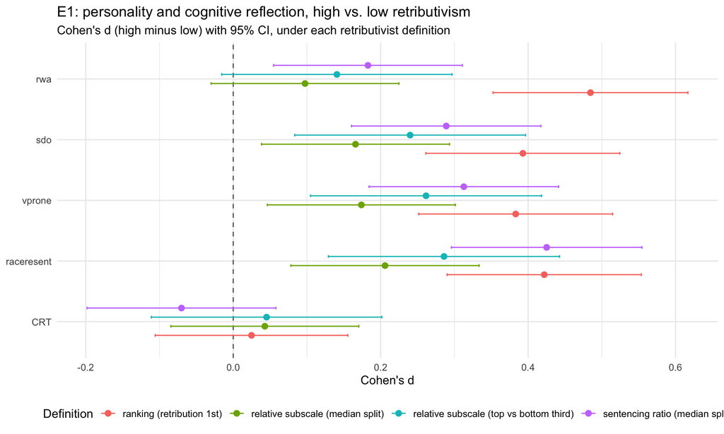

```
## Saved: output/figures/E1_personality_effects.png
```

```r
# ===========================================================================
# PHASE 2.6 — E1 FOREST PLOT
# ---------------------------------------------------------------------------
# One panel showing Cohen's d with its 95% CI for every E1 outcome under every
# retributivist definition. The figure exists to make the convergence question
# visible at a glance: five outcomes x four definitions is twenty numbers, and
# the substantive question is whether the definitions agree on sign and rough
# magnitude, not whether any single cell clears .05.
#
# PRODUCES: output/figures/E1_personality_effects.png.
# ===========================================================================
if (!is.null(e1_all) && nrow(e1_all)) {
  plot_df <- e1_all
  # rev() because ggplot draws the first factor level at the BOTTOM of a
  # discrete y axis; reversing puts the outcomes in e1_vars order top to bottom,
  # matching the tables above.
  plot_df$variable <- factor(plot_df$variable, levels = rev(e1_vars))
  p_e1 <- ggplot2::ggplot(plot_df,
                          ggplot2::aes(x = d, y = variable, colour = grouping)) +
    # Reference line at d = 0, the no-difference point. An interval crossing it
    # is the visual equivalent of a two-sided test failing at alpha = .05.
    ggplot2::geom_vline(xintercept = 0, linetype = "dashed", colour = "grey40") +
    # Horizontal CI bars, dodged so the four definitions for one outcome sit as
    # a legible stack rather than overprinting one another.
    ggplot2::geom_errorbarh(ggplot2::aes(xmin = d_lo, xmax = d_hi),
                            height = 0.18,
                            position = ggplot2::position_dodge(width = 0.6)) +
    # Same dodge width as the bars, so each point stays centred on its interval.
    ggplot2::geom_point(size = 2.4,
                        position = ggplot2::position_dodge(width = 0.6)) +
    ggplot2::labs(
      title = "E1: personality and cognitive reflection, high vs. low retributivism",
      subtitle = "Cohen's d (high minus low) with 95% CI, under each retributivist definition",
      x = "Cohen's d", y = NULL, colour = "Definition") +
    ggplot2::theme_minimal(base_size = 12) +
    ggplot2::theme(legend.position = "bottom")
  print(p_e1)
  ggplot2::ggsave(file.path(OUT_FIGURES, "E1_personality_effects.png"),
                  p_e1, width = 10, height = 6, dpi = 150)
  cat("Saved: output/figures/E1_personality_effects.png\n")
}
```

# PHASE 3: E2 — HOSTILE VS. DURKHEIMIAN SOLIDARITY (STEIGER’S TEST)

**E2.** Hostile solidarity (social exclusion of offenders) relates to punitiveness more strongly than Durkheimian solidarity (punishment as expressing shared norms and binding the law-abiding together).

Two things fix the specification. First, Section 5.3 drops `Solidarity_1` (“Removing criminals from society helps society cleanse itself”) from the Durkheimian reading because it reads as exclusionary; the Durkheimian composite is `Solidarity_2` + `Solidarity_3` only. Second, the punitiveness measure is the **8-item self-report scale**, not the full index: nothing here needs the sentence, and the self-report scale keeps the comparison clean.

The two correlations share `punitiveness`, so they are dependent and **overlapping** — Steiger’s (1980) test, one-sided in the predicted direction.

```r
# ===========================================================================
# PHASE 3.1 — E2 COMPONENT DESCRIPTIVES
# ---------------------------------------------------------------------------
# WHAT THIS CHUNK DOES: prints the composition of the E2 measures and their n,
# mean, and SD, so the correlations in 3.2 can be read against the spread that
# produced them. A composite with almost no variance can only produce a small r
# whatever the underlying relationship, and the reader needs to see that first.
#
# `solidarity_all` appears here even though it is not part of E2 proper: it is
# the sensitivity composite Phase 3.3 uses, and showing its descriptives beside
# solidarity_durk makes visible how much adding Solidarity_1 moves the scale.
# ===========================================================================
cat("E2 components:\n")
```

```
## E2 components:
```

```r
cat("  hostile solidarity   = exclusion (exclusion_1..3)\n")
```

```
##   hostile solidarity   = exclusion (exclusion_1..3)
```

```r
cat("  Durkheimian solidarity = solidarity_durk (Solidarity_2, Solidarity_3)\n")
```

```
##   Durkheimian solidarity = solidarity_durk (Solidarity_2, Solidarity_3)
```

```r
cat("  Solidarity_1 is DROPPED per Section 5.3 (exclusionary, not Durkheimian)\n\n")
```

```
##   Solidarity_1 is DROPPED per Section 5.3 (exclusionary, not Durkheimian)
```

```r
e2_desc <- data.frame(
  measure = c("punitiveness (8-item)", "exclusion (hostile)",
              "solidarity_durk (Durkheimian)", "solidarity_all (sensitivity)"),
  n  = sapply(c("punitiveness", "exclusion", "solidarity_durk", "solidarity_all"),
              function(v) sum(!is.na(d[[v]]))),
  M  = sapply(c("punitiveness", "exclusion", "solidarity_durk", "solidarity_all"),
              function(v) mean(d[[v]], na.rm = TRUE)),
  SD = sapply(c("punitiveness", "exclusion", "solidarity_durk", "solidarity_all"),
              function(v) stats::sd(d[[v]], na.rm = TRUE)),
  stringsAsFactors = FALSE)
show_table(e2_desc, caption = "E2 — component descriptives")
```

E2 — component descriptives

| measure | n | M | SD |
| --- | --- | --- | --- |
| punitiveness (8-item) | 948 | 4.080 | 1.280 |
| exclusion (hostile) | 948 | 4.498 | 1.417 |
| solidarity_durk (Durkheimian) | 948 | 5.129 | 1.231 |
| solidarity_all (sensitivity) | 948 | 5.088 | 1.260 |

```r
# ===========================================================================
# PHASE 3.2 — E2: STEIGER'S TEST
# ---------------------------------------------------------------------------
# WHAT THIS CHUNK DOES: reports the three correlations that enter Steiger's test
# individually, then the test itself.
#
# IMPLEMENTS: E2 (Section 2.4), by the method Section 6.6 specifies.
#
# WHY ALL THREE r's ARE SHOWN FIRST: the test's verdict depends on r(hostile,
# Durkheimian) as much as on the two focal coefficients. Two competitors that
# are themselves highly correlated share most of their sampling error, so even a
# large gap between them can fail to reach significance; two that are nearly
# independent can separate on a smaller gap. Printing r_between makes that
# visible instead of leaving the reader to wonder why a difference of a given
# size did or did not clear alpha.
#
# WHY ONE-SIDED: E2 names a direction ("more strongly than"), so Section 6.8
# puts it one-sided in that direction. alternative = "greater" tests
# r(punitiveness, hostile) > r(punitiveness, Durkheimian); a result in the
# opposite direction returns a p above .5 rather than a small one, which is the
# correct behaviour for a directional prediction that failed.
#
# PRODUCES: `e2` (list) and `e2_tab`, both reused by the Phase 3.3 spec table.
# ===========================================================================

# The three coefficients with their 95% CIs, per Section 6.8's requirement that
# every test report an effect size and an interval.
e2_cors <- rbind(
  c(pair = NA, get_cor_ci("punitiveness", "exclusion", d)),
  c(pair = NA, get_cor_ci("punitiveness", "solidarity_durk", d)),
  c(pair = NA, get_cor_ci("exclusion",    "solidarity_durk", d))
)
# get_cor_ci() returns a numeric vector, so a character label cannot be rbind-ed
# alongside it without coercing everything to character. The placeholder column
# is therefore created as NA, dropped by [, -1], and the labels attached after
# the frame exists.
e2_cors <- as.data.frame(e2_cors[, -1, drop = FALSE])
e2_cors$pair <- c("punitiveness x hostile solidarity",
                  "punitiveness x Durkheimian solidarity",
                  "hostile x Durkheimian solidarity")
e2_cors <- e2_cors[, c("pair", "r", "ci_lower", "ci_upper", "p", "n")]
show_table(e2_cors, caption = "E2 — the three correlations entering Steiger's test")
```

E2 — the three correlations entering Steiger’s test

| pair | r | ci_lower | ci_upper | p | n |
| --- | --- | --- | --- | --- | --- |
| punitiveness x hostile solidarity | 0.625 | 0.585 | 0.662 | 0 | 948 |
| punitiveness x Durkheimian solidarity | 0.530 | 0.483 | 0.575 | 0 | 948 |
| hostile x Durkheimian solidarity | 0.504 | 0.455 | 0.550 | 0 | 948 |

```r
# `punitiveness` is the SHARED variable j, which is what makes these two
# correlations overlapping rather than merely dependent.
#
# HAZARD: this must be the 8-item self-report punitiveness scale, not
# punitiveness_full. Nothing in E2 needs the sentence, and swapping in the full
# index would drag Sentence1_z into both coefficients and change what the test
# is comparing.
e2 <- steiger_overlap(d, "punitiveness", "exclusion", "solidarity_durk",
                      alternative = "greater")
e2_tab <- if (is.null(e2)) NULL else e2$table

show_table(e2_tab, caption = "E2 — Steiger's test (one-sided: hostile > Durkheimian)")
```

E2 — Steiger’s test (one-sided: hostile > Durkheimian)

| shared | comparison_1 | comparison_2 | r_1 | r_2 | r_between | diff | n | steiger_z | p | alternative |
| --- | --- | --- | --- | --- | --- | --- | --- | --- | --- | --- |
| punitiveness | exclusion | solidarity_durk | 0.625 | 0.53 | 0.504 | 0.095 | 948 | 3.841 | 0 | greater |

```r
if (is.null(e2_tab)) {
  cat("Steiger's test could not be computed (insufficient complete cases).\n")
} else {
  cat(sprintf(
    "r(punitiveness, hostile) = %.3f vs r(punitiveness, Durkheimian) = %.3f\n",
    e2_tab$r_1, e2_tab$r_2))
  cat(sprintf("difference = %.3f, Steiger z = %.3f, one-sided p %s\n",
              e2_tab$diff, e2_tab$steiger_z, format_p(e2_tab$p)))
  # alpha = .05 is the Section 6.8 threshold. The verdict is worded "in this
  # sample" because E2 is exploratory: Section 6.6 keeps it out of the
  # confirmatory machinery, so a small p here marks a claim worth testing
  # confirmatorily in a future study rather than an established effect.
  cat(sprintf("Conclusion at alpha = .05: E2 %s\n",
              ifelse(!is.na(e2_tab$p) && e2_tab$p < .05,
                     "SUPPORTED in this sample", "not supported in this sample")))
}
```

```
## r(punitiveness, hostile) = 0.625 vs r(punitiveness, Durkheimian) = 0.530
## difference = 0.095, Steiger z = 3.841, one-sided p < .001
## Conclusion at alpha = .05: E2 SUPPORTED in this sample
```

```r
# ===========================================================================
# PHASE 3.3 — E2 SPECIFICATION CHECKS
# ---------------------------------------------------------------------------
# WHAT THIS CHUNK DOES: reruns E2 under two alternative specifications and
# stacks all three side by side, so the preregistered result can be read next to
# the choices that produced it.
#
# PRODUCES: `e2_sens_tab`; output/tables/E2_solidarity_steiger.csv.
# ===========================================================================

# Sensitivity 1: put Solidarity_1 back into the Durkheimian composite.
# This is the specification a reader who disagrees with the Section 5.3 item
# judgement would run. Since Solidarity_1 ("Removing criminals from society
# helps society cleanse itself") reads as exclusionary, including it should move
# the Durkheimian composite TOWARD the hostile one, shrinking the very
# difference E2 predicts. If E2 holds in the preregistered specification and
# weakens here, that pattern is itself evidence the item is exclusionary; if the
# two specifications agree, the item choice was not load-bearing. Either way the
# reader gets to judge, which is why both are printed rather than one.
e2_sens <- steiger_overlap(d, "punitiveness", "exclusion", "solidarity_all",
                           alternative = "greater")

# Sensitivity 2: E2 inside the retributivist group only (Section 5.3 asks for
# every contrast under each measure; H11 reruns the whole-sample tests there).
# The ranking definition is used because it is the primary categorical grouping.
# Restricting to it costs statistical power, so a weaker result here is expected
# on n alone and should not be read as a failure to replicate.
d_retrib <- d[!is.na(d$retributivist) & d$retributivist == 1, , drop = FALSE]
e2_retrib <- steiger_overlap(d_retrib, "punitiveness", "exclusion",
                             "solidarity_durk", alternative = "greater")

# cbind() prefixes each table with a `spec` column naming its specification, so
# the stacked table can never be read without knowing which row is which. The
# preregistered row is listed first and labelled as such.
e2_sens_tab <- do.call(rbind, Filter(Negate(is.null), list(
  if (!is.null(e2))        cbind(spec = "preregistered (S2+S3, whole sample)", e2$table),
  if (!is.null(e2_sens))   cbind(spec = "sensitivity: Solidarity_1 included",  e2_sens$table),
  if (!is.null(e2_retrib)) cbind(spec = "retributivists only (ranking)",       e2_retrib$table)
)))
show_table(e2_sens_tab, caption = "E2 — specification checks")
```

E2 — specification checks

| spec | shared | comparison_1 | comparison_2 | r_1 | r_2 | r_between | diff | n | steiger_z | p | alternative |
| --- | --- | --- | --- | --- | --- | --- | --- | --- | --- | --- | --- |
| preregistered (S2+S3, whole sample) | punitiveness | exclusion | solidarity_durk | 0.625 | 0.530 | 0.504 | 0.095 | 948 | 3.841 | 0.000 | greater |
| sensitivity: Solidarity_1 included | punitiveness | exclusion | solidarity_all | 0.625 | 0.618 | 0.573 | 0.007 | 948 | 0.322 | 0.374 | greater |
| retributivists only (ranking) | punitiveness | exclusion | solidarity_durk | 0.556 | 0.380 | 0.397 | 0.176 | 371 | 3.670 | 0.000 | greater |

```r
if (!is.null(e2_sens_tab))
  readr::write_csv(e2_sens_tab, file.path(OUT_TABLES, "E2_solidarity_steiger.csv"))
cat("\nWrote output/tables/E2_solidarity_steiger.csv\n")
```

```
##
## Wrote output/tables/E2_solidarity_steiger.csv
```

# PHASE 4: FACTOR STRUCTURE OF THE CORRELATES (EFA + SCREE)

Section 6.6 asks for “the factor structure of the correlates” as an exploratory extension of H3, which summarizes the intercorrelations by “the share that are positive and by the first eigenvalue and scree of an exploratory factor analysis.” The correlate set is the one named in H1.

```r
# ===========================================================================
# PHASE 4.1 — THE CORRELATE INTERCORRELATION MATRIX
# ---------------------------------------------------------------------------
# WHAT THIS CHUNK DOES: assembles the twelve H1 correlates, reports the share of
# positive intercorrelations, the mean and range, and the eigenvalues.
#
# IMPLEMENTS: the exploratory extension of H3 that Section 6.6 asks for. H3
# itself (Section 6.3) summarizes the correlate intercorrelations "by the share
# that are positive and by the first eigenvalue and scree of an exploratory
# factor analysis, to see whether one punitiveness dimension runs through them."
# This is that question asked one level deeper -- not just how big the first
# eigenvalue is, but what the factors look like once extracted.
#
# NO HYPOTHESIS TEST LIVES HERE. This is a descriptive decomposition with no
# null, which is one of the concrete reasons a single BH sweep across this
# document would be meaningless: there is nothing in this phase for a
# false-discovery rate to be a rate OF.
#
# OBJECTS CREATED: correlates, efa_data, cm, ev -- all used by 4.2 and 4.3.
# PRODUCES: output/tables/EFA_correlate_intercorrelations.csv.
# ===========================================================================

# The H1 correlate set, in the order Sections 5.5 - 5.9 introduce them: the
# Kantian limits, the emotions, exclusion, the harshness measures, revenge, and
# the crime concerns. Every one is scored so that HIGHER = more punitive, which
# is what makes "share positive" a meaningful summary rather than an artifact of
# keying: a mixed-key set would show negative cells that mean agreement.
correlates <- intersect(
  c("dueprocess", "uncertain", "hatred", "anger", "exclusion", "degradation",
    "suffering", "prisonviol", "harsh", "revenge", "crimerates", "fear"),
  names(d))

# LISTWISE for the factor analysis: psych::fa() needs one covariance matrix from
# one set of rows, and a pairwise matrix can come out non-positive-definite,
# producing Heywood cases and impossible communalities.
efa_data <- d[, correlates, drop = FALSE]
efa_data <- efa_data[stats::complete.cases(efa_data), , drop = FALSE]
cat(sprintf("EFA on %d correlates, complete cases N = %d\n",
            length(correlates), nrow(efa_data)))
```

```
## EFA on 12 correlates, complete cases N = 948
```

```r
# PAIRWISE for the descriptive matrix, which is the opposite choice and a
# deliberate one: the printed r's and the share-positive count should use every
# available pair rather than being restricted to the listwise subset, so each
# cell is the best estimate of that particular correlation.
cm <- stats::cor(d[, correlates], use = "pairwise.complete.obs")
# upper.tri() takes each pair once: 12 correlates give 12*11/2 = 66 unique
# off-diagonal cells, and using the full matrix would double-count every one.
offdiag <- cm[upper.tri(cm)]
cat(sprintf("\nShare of positive intercorrelations: %s (%d of %d)\n",
            pct(mean(offdiag > 0)), sum(offdiag > 0), length(offdiag)))
```

```
##
## Share of positive intercorrelations: 100.0% (66 of 66)
```

```r
cat(sprintf("Mean intercorrelation: r = %.3f (range %.3f to %.3f)\n",
            mean(offdiag), min(offdiag), max(offdiag)))
```

```
## Mean intercorrelation: r = 0.434 (range 0.049 to 0.705)
```

```r
# Eigenvalues of the CORRELATION matrix, so they sum to the number of variables
# (12) and each one reads as "how many variables' worth of variance". A large
# first eigenvalue relative to the rest is what "one punitiveness dimension runs
# through them" would look like.
ev <- eigen(cm)$values
cat(sprintf("First eigenvalue: %.2f of %d (%s of the variance)\n",
            ev[1], length(ev), pct(ev[1] / sum(ev))))
```

```
## First eigenvalue: 5.95 of 12 (49.5% of the variance)
```

```r
# The Kaiser criterion: a component with an eigenvalue above 1 accounts for more
# variance than a single standardized variable does. It is reported because it
# is conventional and because it anchors the dashed line on the scree plot, but
# it is known to over-retain, which is why the number of factors actually
# extracted in 4.3 comes from parallel analysis instead.
cat(sprintf("Eigenvalues > 1: %d\n", sum(ev > 1)))
```

```
## Eigenvalues > 1: 2
```

```r
# The zero matrix passed as p_matrix stars every off-diagonal cell. That is
# intentional: this table displays the SIGN PATTERN that H3 summarizes, and its
# 66 cells are not 66 tests. Passing real p-values would invite exactly the
# cell-by-cell reading Section 6.6 rules out for this document.
show_table(format_cor_table(cm, matrix(0, nrow(cm), ncol(cm),
                                       dimnames = dimnames(cm)), 2),
           caption = "Intercorrelations among the H1 correlates")
```

Intercorrelations among the H1 correlates

| dueprocess | uncertain | hatred | anger | exclusion | degradation | suffering | prisonviol | harsh | revenge | crimerates | fear |
| --- | --- | --- | --- | --- | --- | --- | --- | --- | --- | --- | --- |
| - | 0.54*** | 0.47*** | 0.42*** | 0.41*** | 0.47*** | 0.52*** | 0.32*** | 0.58*** | 0.50*** | 0.40*** | 0.28*** |
| 0.54*** | - | 0.43*** | 0.36*** | 0.38*** | 0.38*** | 0.45*** | 0.28*** | 0.49*** | 0.43*** | 0.23*** | 0.18*** |
| 0.47*** | 0.43*** | - | 0.71*** | 0.60*** | 0.60*** | 0.61*** | 0.43*** | 0.62*** | 0.63*** | 0.41*** | 0.30*** |
| 0.42*** | 0.36*** | 0.71*** | - | 0.47*** | 0.44*** | 0.49*** | 0.21*** | 0.49*** | 0.50*** | 0.53*** | 0.39*** |
| 0.41*** | 0.38*** | 0.60*** | 0.47*** | - | 0.56*** | 0.52*** | 0.36*** | 0.54*** | 0.55*** | 0.36*** | 0.18*** |
| 0.47*** | 0.38*** | 0.60*** | 0.44*** | 0.56*** | - | 0.67*** | 0.45*** | 0.69*** | 0.57*** | 0.28*** | 0.20*** |
| 0.52*** | 0.45*** | 0.61*** | 0.49*** | 0.52*** | 0.67*** | - | 0.41*** | 0.70*** | 0.64*** | 0.38*** | 0.24*** |
| 0.32*** | 0.28*** | 0.43*** | 0.21*** | 0.36*** | 0.45*** | 0.41*** | - | 0.55*** | 0.42*** | 0.13*** | 0.05*** |
| 0.58*** | 0.49*** | 0.62*** | 0.49*** | 0.54*** | 0.69*** | 0.70*** | 0.55*** | - | 0.59*** | 0.37*** | 0.23*** |
| 0.50*** | 0.43*** | 0.63*** | 0.50*** | 0.55*** | 0.57*** | 0.64*** | 0.42*** | 0.59*** | - | 0.38*** | 0.18*** |
| 0.40*** | 0.23*** | 0.41*** | 0.53*** | 0.36*** | 0.28*** | 0.38*** | 0.13*** | 0.37*** | 0.38*** | - | 0.46*** |
| 0.28*** | 0.18*** | 0.30*** | 0.39*** | 0.18*** | 0.20*** | 0.24*** | 0.05*** | 0.23*** | 0.18*** | 0.46*** | - |

```r
readr::write_csv(
  data.frame(variable = rownames(cm), round(cm, 3), check.names = FALSE),
  file.path(OUT_TABLES, "EFA_correlate_intercorrelations.csv"))
```

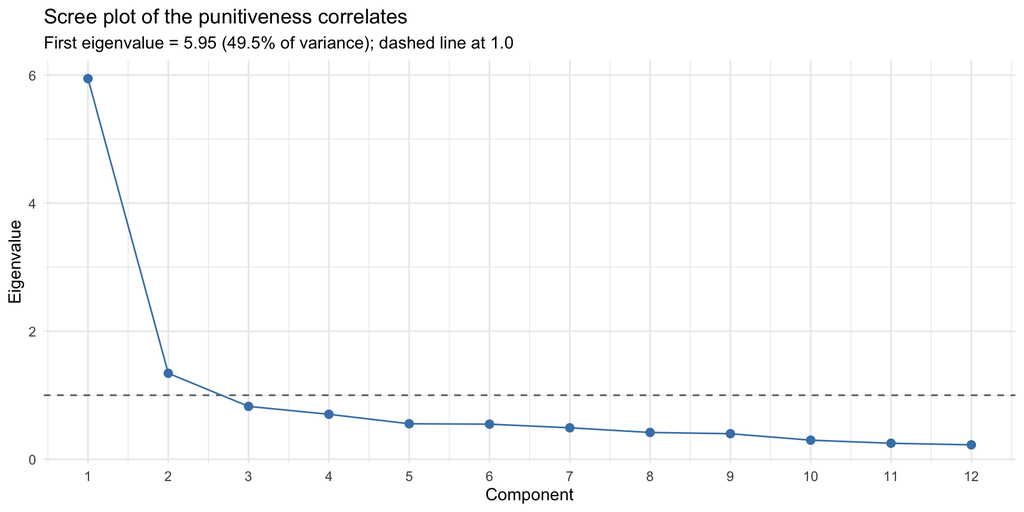

```r
# ===========================================================================
# PHASE 4.2 — SCREE PLOT
# ---------------------------------------------------------------------------
# The scree Section 6.3 names as part of the H3 summary. Read it for the ELBOW:
# a single steep drop from the first eigenvalue into a flat tail is the shape a
# one-dimensional punitiveness construct produces, while two comparable
# eigenvalues before the flattening indicate the correlates split.
#
# PRODUCES: output/figures/EFA_scree_correlates.png.
# ===========================================================================
scree_df <- data.frame(factor = seq_along(ev), eigenvalue = ev)
p_scree <- ggplot2::ggplot(scree_df, ggplot2::aes(x = factor, y = eigenvalue)) +
  # The Kaiser line at 1.0: a component below it explains less than one
  # standardized variable's worth of variance.
  ggplot2::geom_hline(yintercept = 1, linetype = "dashed", colour = "grey40") +
  ggplot2::geom_line(colour = "steelblue") +
  ggplot2::geom_point(size = 2.4, colour = "steelblue") +
  # One break per component: the x axis is a count, so ggplot's default
  # continuous breaks would print meaningless half-components.
  ggplot2::scale_x_continuous(breaks = scree_df$factor) +
  ggplot2::labs(
    title = "Scree plot of the punitiveness correlates",
    subtitle = sprintf("First eigenvalue = %.2f (%s of variance); dashed line at 1.0",
                       ev[1], pct(ev[1] / sum(ev))),
    x = "Component", y = "Eigenvalue") +
  ggplot2::theme_minimal(base_size = 12)
print(p_scree)
```

```r
ggplot2::ggsave(file.path(OUT_FIGURES, "EFA_scree_correlates.png"),
                p_scree, width = 9, height = 5, dpi = 150)
cat("Saved: output/figures/EFA_scree_correlates.png\n")
```

```
## Saved: output/figures/EFA_scree_correlates.png
```

```r
# ===========================================================================
# PHASE 4.3 — EXPLORATORY FACTOR ANALYSIS
# ---------------------------------------------------------------------------
# WHAT THIS CHUNK DOES: chooses a number of factors by parallel analysis,
# extracts at that solution, and prints the loadings twice -- once in full, once
# with small loadings suppressed.
#
# PRODUCES: `efa_fit`, `load_df`, `disp`;
#           output/tables/EFA_correlate_loadings.csv.
# ===========================================================================

# Parallel analysis for the number of factors, then an EFA at that solution.
# WHY PARALLEL ANALYSIS: it compares each observed eigenvalue against the
# eigenvalues of random data with the same n and the same number of variables,
# and retains a factor only when it beats what chance alone produces at this
# sample size. That is a stricter and better-calibrated rule than the Kaiser
# criterion reported in 4.1, which over-retains as the variable count grows.
# fa = "fa" runs the comparison on the common-factor solution rather than on
# principal components, matching the psych::fa() extraction used below.
# n.iter = 50 random datasets is enough for a stable count at N in the hundreds.
# The max(1, min(., 4)) clamp is a guardrail, not a finding: it keeps a
# degenerate result from requesting zero factors (which errors) or more factors
# than twelve correlates can support with interpretable loadings. A solution
# that hits the ceiling of 4 should be read as "at least four", and the
# eigenvalues in 4.1 are the check on that.
n_fac <- tryCatch({
  pa <- psych::fa.parallel(efa_data, fa = "fa", n.iter = 50,
                           plot = FALSE, show.legend = FALSE)
  max(1, min(pa$nfact, 4))
}, error = function(e) { cat("Parallel analysis failed:", conditionMessage(e), "\n"); 2 })
```

```
## Parallel analysis suggests that the number of factors =  3  and the number of components =  NA
```

```r
cat(sprintf("Factors retained: %d\n\n", n_fac))
```

```
## Factors retained: 3
```

```r
# ROTATION. Oblimin is OBLIQUE: it lets the extracted factors correlate, which
# is the theoretically right assumption here, since H3 is precisely the claim
# that one punitiveness dimension runs through the correlates. Forcing the
# factors orthogonal with varimax would assume that answer away -- it would
# guarantee uncorrelated factors and then invite the reader to conclude the
# correlates are independent. The varimax branch exists only so the document
# knits without GPArotation; when HAS_GPA is FALSE the loadings change and the
# Phi matrix below disappears, so the rotation actually used is printed in the
# table caption rather than assumed.
rot <- if (HAS_GPA) "oblimin" else "varimax"
# fm = "ml" is maximum likelihood, which yields interpretable fit statistics and
# is the natural companion to a factor model. It can fail to converge on a
# near-singular matrix, so the fallback drops to psych::fa()'s default minres
# (ordinary least squares), which is far more forgiving; the message names which
# one ran so nobody compares an ML solution against an OLS one unknowingly.
efa_fit <- tryCatch(
  psych::fa(efa_data, nfactors = n_fac, rotate = rot, fm = "ml"),
  error = function(e) {
    cat("ML extraction failed, falling back to minres:", conditionMessage(e), "\n")
    tryCatch(psych::fa(efa_data, nfactors = n_fac, rotate = rot),
             error = function(e2) NULL)
  })

load_df <- NULL
disp    <- NULL
if (!is.null(efa_fit)) {
  # unclass() strips psych's "loadings" class, whose print method hides small
  # values by default -- exactly the suppression this chunk wants to control
  # explicitly rather than inherit.
  load_mat <- unclass(efa_fit$loadings)
  # h2 is the COMMUNALITY: the share of each correlate's variance the retained
  # factors account for. A correlate with a low h2 is one the factor solution
  # essentially fails to explain, which matters as much as a high loading does.
  load_df  <- data.frame(variable = rownames(load_mat),
                         round(load_mat, 3),
                         h2 = round(efa_fit$communality, 3),
                         # check.names = FALSE keeps psych's factor column names
                         # (ML1, ML2, ...) intact.
                         check.names = FALSE, stringsAsFactors = FALSE)
  # Suppressed view: loadings below |.30| blanked, for readability.
  # .30 is the conventional threshold for a loading worth interpreting: it is
  # roughly where a variable shares 9% of its variance with a factor. The
  # ABSOLUTE value is what matters, so a strong negative loading survives.
  # BOTH views are printed rather than only the suppressed one, because
  # suppression hides cross-loadings, and a correlate loading .28 on two factors
  # is a substantively different finding from one loading .28 on neither.
  # The same .30 threshold marks a near-zero loading in the H6 factor model
  # (Section 6.4), where poor fit OR a loading below it counts as failure to
  # cohere; that test lives in 01_main_analysis.Rmd, not here.
  disp <- load_df
  # Everything except the label and the communality column is a factor column.
  fac_cols <- setdiff(names(disp), c("variable", "h2"))
  # sprintf() converts the survivors to character, so each factor column becomes
  # character as a whole and the blanks sit in it without coercion warnings.
  for (cc in fac_cols)
    disp[[cc]] <- ifelse(abs(disp[[cc]]) < .30, "", sprintf("%.2f", disp[[cc]]))
}

show_table(load_df,
           caption = sprintf("EFA loadings (%d factors, %s rotation, ML)", n_fac, rot))
```

EFA loadings (3 factors, oblimin rotation, ML)

| variable | ML1 | ML3 | ML2 | h2 |
| --- | --- | --- | --- | --- |
| dueprocess | 0.666 | -0.103 | 0.255 | 0.494 |
| uncertain | 0.538 | 0.002 | 0.094 | 0.329 |
| hatred | 0.107 | 0.868 | -0.055 | 0.864 |
| anger | -0.037 | 0.688 | 0.304 | 0.683 |
| exclusion | 0.393 | 0.349 | -0.007 | 0.473 |
| degradation | 0.718 | 0.127 | -0.092 | 0.627 |
| suffering | 0.756 | 0.054 | 0.055 | 0.662 |
| prisonviol | 0.613 | 0.050 | -0.237 | 0.388 |
| harsh | 0.886 | -0.032 | 0.021 | 0.755 |
| revenge | 0.546 | 0.246 | 0.019 | 0.565 |
| crimerates | 0.145 | 0.118 | 0.644 | 0.586 |
| fear | 0.014 | 0.135 | 0.514 | 0.343 |

```r
show_table(disp, caption = "EFA loadings with |lambda| < .30 suppressed")
```

EFA loadings with |lambda| < .30 suppressed

| variable | ML1 | ML3 | ML2 | h2 |
| --- | --- | --- | --- | --- |
| dueprocess | 0.67 |  |  | 0.494 |
| uncertain | 0.54 |  |  | 0.329 |
| hatred |  | 0.87 |  | 0.864 |
| anger |  | 0.69 | 0.30 | 0.683 |
| exclusion | 0.39 | 0.35 |  | 0.473 |
| degradation | 0.72 |  |  | 0.627 |
| suffering | 0.76 |  |  | 0.662 |
| prisonviol | 0.61 |  |  | 0.388 |
| harsh | 0.89 |  |  | 0.755 |
| revenge | 0.55 |  |  | 0.565 |
| crimerates |  |  | 0.64 | 0.586 |
| fear |  |  | 0.51 | 0.343 |

```r
if (is.null(efa_fit)) {
  cat("EFA could not be estimated on this sample.\n")
} else {
  # Row 2 of Vaccounted is "Proportion Var", the share of total variance each
  # factor explains. (Row 1 is the raw SS loadings, row 3 the cumulative share.)
  cat(sprintf("Proportion of variance explained: %s\n",
              paste(sprintf("%.1f%%", 100 * efa_fit$Vaccounted[2, ]),
                    collapse = ", ")))
  # Phi is the factor intercorrelation matrix and EXISTS ONLY under an oblique
  # rotation -- varimax constrains it to the identity, so psych returns NULL and
  # the guard skips it. This is the most directly H3-relevant number in the
  # phase: strongly correlated factors say the correlates are facets of one
  # punitiveness dimension, while near-zero Phi says they are genuinely separate
  # even though an oblique rotation was free to let them correlate.
  if (n_fac > 1 && !is.null(efa_fit$Phi)) {
    cat("\nFactor intercorrelations (Phi):\n")
    print(round(efa_fit$Phi, 3))
  }
  readr::write_csv(load_df, file.path(OUT_TABLES, "EFA_correlate_loadings.csv"))
  cat("\nWrote output/tables/EFA_correlate_loadings.csv\n")
}
```

```
## Proportion of variance explained: 31.8%, 15.7%, 8.9%
##
## Factor intercorrelations (Phi):
##      ML1   ML3   ML2
## ML1 1.00 0.730 0.280
## ML3 0.73 1.000 0.384
## ML2 0.28 0.384 1.000
##
## Wrote output/tables/EFA_correlate_loadings.csv
```

# PHASE 5: CHANGE FROM THE FIRST TO THE SECOND SENTENCE

The second sentence is set after the forward-looking reasons for punishment are removed (the defendant is permanently disabled and no longer a danger, and procedural rules remove any prospect of general deterrence). Whatever punishment survives that removal reflects desert (Section 5.11).

Two indices are examined: the raw change (`Sentence2 - Sentence1`), and the pre-registered **sentencing ratio** (`Sentence2 / Sentence1` for participants whose first sentence was above zero). Section 5.11 prefers the ratio because the raw drop is bounded by the first sentence and piles up at zero, and it asks for the **regression-adjusted** version — the second sentence residualized on the first — as a robustness check. Section 5.11 also asks that results be confirmed **within each vignette**.

Throughout this phase, punitiveness is the 8-item self-report scale: the sentence is on the other side of every test here, so the full index would double-count it.

## 5.1 Descriptives of the change

```r
# ===========================================================================
# PHASE 5.1 — DESCRIPTIVES OF THE SENTENCE CHANGE
# ---------------------------------------------------------------------------
# WHAT THIS CHUNK DOES: describes both change indices, tests the drop with a
# paired t-test, reports the two boundary behaviours (no reduction at all, and
# reduction to zero), and breaks the whole picture down by vignette.
#
# IMPLEMENTS: the first-to-second sentence analysis Section 6.6 asks for,
# specified in Section 5.11.
# OBJECTS CREATED: `sentence_delta`, used by 5.2 and saved in Phase 9.
# ===========================================================================

# The raw change. NEGATIVE means the participant reduced the sentence, which is
# the expected direction once the forward-looking reasons are removed.
# Section 5.11 prefers the ratio to this index "because the raw drop is bounded
# by the first sentence and is expected to pile up at zero" -- someone who set
# 5 years cannot drop by more than 5, so the raw change confounds the size of
# the reduction with the size of the original sentence. Both are reported; the
# ratio is the one carried into the analyses below.
d$sentence_delta <- d$Sentence2 - d$Sentence1

# The median is shown alongside the mean throughout, because both indices are
# expected to be skewed with mass at a boundary and the mean alone would
# misdescribe the typical participant.
sent_desc <- data.frame(
  measure = c("Sentence1 (years)", "Sentence2 (years)",
              "change (S2 - S1)", "ratio (S2 / S1)"),
  n = c(sum(!is.na(d$Sentence1)), sum(!is.na(d$Sentence2)),
        sum(!is.na(d$sentence_delta)), sum(!is.na(d$sentence_ratio))),
  M = c(mean(d$Sentence1, na.rm = TRUE), mean(d$Sentence2, na.rm = TRUE),
        mean(d$sentence_delta, na.rm = TRUE), mean(d$sentence_ratio, na.rm = TRUE)),
  SD = c(stats::sd(d$Sentence1, na.rm = TRUE), stats::sd(d$Sentence2, na.rm = TRUE),
         stats::sd(d$sentence_delta, na.rm = TRUE), stats::sd(d$sentence_ratio, na.rm = TRUE)),
  Median = c(stats::median(d$Sentence1, na.rm = TRUE),
             stats::median(d$Sentence2, na.rm = TRUE),
             stats::median(d$sentence_delta, na.rm = TRUE),
             stats::median(d$sentence_ratio, na.rm = TRUE)),
  stringsAsFactors = FALSE)
show_table(sent_desc, caption = "First and second sentence, and the change between them")
```

First and second sentence, and the change between them

| measure | n | M | SD | Median |
| --- | --- | --- | --- | --- |
| Sentence1 (years) | 948 | 36.188 | 12.761 | 35 |
| Sentence2 (years) | 948 | 29.447 | 16.699 | 26 |
| change (S2 - S1) | 948 | -6.741 | 10.572 | 0 |
| ratio (S2 / S1) | 947 | 0.783 | 0.338 | 1 |

```r
# PAIRED, not two-sample: both sentences come from the same participant about
# the same case, so the pairing removes between-participant differences in
# baseline punitiveness and tests only the within-person change. An unpaired
# test here would be answering a different and much less interesting question.
# Two-sided: this is a descriptive check that the manipulation moved sentences
# at all, not one of the directional predictions Section 6.8 tests one-sided.
tt_sent <- stats::t.test(d$Sentence2, d$Sentence1, paired = TRUE)
cat(sprintf("\nPaired test of the drop: t(%.0f) = %.2f, p %s, mean change = %.2f years\n",
            tt_sent$parameter, tt_sent$statistic, format_p(tt_sent$p.value),
            unname(tt_sent$estimate)))
```

```
##
## Paired test of the drop: t(947) = -19.63, p < .001, mean change = -6.74 years
```

```r
# The two boundary behaviours, reported because they are the substantive
# extremes rather than nuisance cases. A ratio of 1 or above means the
# participant kept (or raised) the whole sentence after being told the defendant
# is permanently disabled and no longer deterrable -- the purest expression of a
# desert motive the design offers. A ratio of 0 means punishment collapsed once
# the forward-looking reasons were withdrawn, the purely consequentialist
# response. The size of these two groups is the headline of this phase, and it
# also explains why the median split on the ratio needs balanced_split().
cat(sprintf("Did NOT reduce at all (ratio >= 1): %s\n",
            pct(mean(d$sentence_ratio >= 1, na.rm = TRUE))))
```

```
## Did NOT reduce at all (ratio >= 1): 54.3%
```

```r
cat(sprintf("Reduced to zero (ratio = 0): %s\n",
            pct(mean(d$sentence_ratio == 0, na.rm = TRUE))))
```

```
## Reduced to zero (ratio = 0): 4.1%
```

```r
# Section 5.11 asks that results be confirmed WITHIN each vignette, because the
# three cases differ in severity. This table sets up that check descriptively;
# 5.4 runs the correlations within vignette.
by_vig <- do.call(rbind, lapply(sort(unique(stats::na.omit(d$Vignette))), function(v) {
  s <- d[!is.na(d$Vignette) & d$Vignette == v, ]
  data.frame(Vignette = v, n = nrow(s),
             M_S1 = mean(s$Sentence1, na.rm = TRUE),
             M_S2 = mean(s$Sentence2, na.rm = TRUE),
             M_change = mean(s$sentence_delta, na.rm = TRUE),
             Median_ratio = stats::median(s$sentence_ratio, na.rm = TRUE),
             stringsAsFactors = FALSE)
}))
show_table(by_vig, caption = "Sentence change by vignette")
```

Sentence change by vignette

| Vignette | n | M_S1 | M_S2 | M_change | Median_ratio |
| --- | --- | --- | --- | --- | --- |
| 1 | 315 | 34.51 | 27.82 | -6.683 | 1.000 |
| 2 | 317 | 38.76 | 32.97 | -5.792 | 1.000 |
| 3 | 316 | 35.28 | 27.53 | -7.750 | 0.879 |

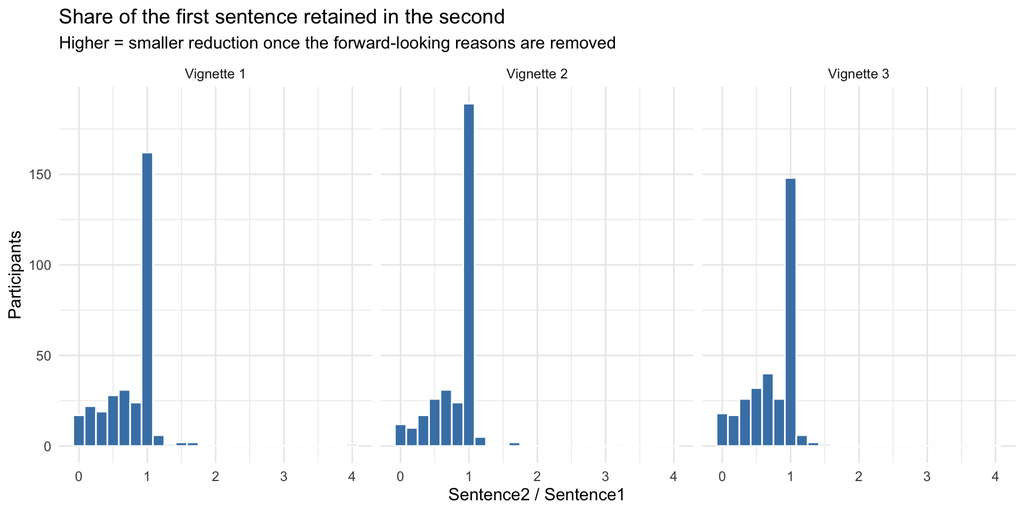

```
## Saved: output/figures/sentence_ratio_by_vignette.png
```

```r
# ===========================================================================
# PHASE 5.2 — DISTRIBUTION OF THE SENTENCING RATIO BY VIGNETTE
# ---------------------------------------------------------------------------
# A histogram rather than a summary statistic, because the SHAPE is the finding.
# Section 5.11 predicts a pile-up, and a mean or median cannot show whether the
# ratio is unimodal or splits into a group that cut deeply and a group that did
# not cut at all. Faceting by vignette also makes the Section 5.11 consistency
# check visible: the ratio is a proportion and therefore comparable across
# vignettes, so the three panels should have similar shapes even though the
# underlying sentences differ in severity.
#
# PRODUCES: output/figures/sentence_ratio_by_vignette.png.
# ===========================================================================
plot_df <- d[!is.na(d$sentence_ratio), c("Vignette", "sentence_ratio"), drop = FALSE]
if (nrow(plot_df)) {
  # sort(unique(...)) so the labels attach to the factor levels in the same
  # numeric order factor() creates them; a mismatch here would silently relabel
  # one vignette as another.
  plot_df$Vignette <- factor(plot_df$Vignette,
                             labels = paste("Vignette", sort(unique(plot_df$Vignette))))
  p_ratio <- ggplot2::ggplot(plot_df, ggplot2::aes(x = sentence_ratio)) +
    # 25 bins is fine enough to resolve the spike at exactly 1.0 without
    # shattering the body of the distribution into noise.
    ggplot2::geom_histogram(bins = 25, fill = "steelblue", colour = "white") +
    # Free-scaled facets are NOT used: the three panels share axes so their
    # shapes can be compared directly, which is the whole point of the check.
    ggplot2::facet_wrap(~ Vignette) +
    ggplot2::labs(
      title = "Share of the first sentence retained in the second",
      subtitle = "Higher = smaller reduction once the forward-looking reasons are removed",
      x = "Sentence2 / Sentence1", y = "Participants") +
    ggplot2::theme_minimal(base_size = 12)
  print(p_ratio)
  ggplot2::ggsave(file.path(OUT_FIGURES, "sentence_ratio_by_vignette.png"),
                  p_ratio, width = 10, height = 5, dpi = 150)
  cat("Saved: output/figures/sentence_ratio_by_vignette.png\n")
}
```

## 5.2 The change as a function of retributivism

```r
# ===========================================================================
# PHASE 5.3 — THE CHANGE AS A FUNCTION OF RETRIBUTIVISM
# ---------------------------------------------------------------------------
# WHAT THIS CHUNK DOES: treats both change indices as OUTCOMES and asks whether
# more retributive participants reduce less. Grouped contrasts first, then the
# continuous regression, then the ratio's correlation with punitiveness.
#
# PRODUCES: `chg_tab`, `chg_cont`; chg_tab is written to
#           output/tables/sentence_change_contrasts.csv in 5.4.
#
# `directions = NULL` on all three contrasts, so every test is TWO-SIDED.
# Section 6.6 lists the sentence change among the report-only analyses and names
# no direction for it, and Section 6.8 reserves one-sided tests for predictions
# that name a direction. E1 and E2 earn one-sided tests; this does not.
# ===========================================================================
change_vars <- c("sentence_delta", "sentence_ratio")

# The sentencing ratio is NOT used to group participants here: it is built from
# the same sentences these outcomes describe (Section 5.3, the H14 restriction).
# grp_ratio would put sentence_ratio on both sides at once and guarantee a large
# effect that means nothing. The same logic bars grp_sem from Phase 5 in
# principle; it is absent here simply because these outcomes are the sentence.
# Three groupings remain: the ranking and the two cuts of the relative subscale.
chg_rank <- run_contrasts(d, change_vars, "grp_rank", NULL,
                          label = "ranking (retribution 1st)")
chg_rel  <- run_contrasts(d, change_vars, "grp_rel", NULL,
                          label = "relative subscale (median split)")
chg_tert <- run_contrasts(d, change_vars, "grp_tert", NULL,
                          label = "relative subscale (top vs bottom third)")

chg_tab <- do.call(rbind, Filter(Negate(is.null), list(chg_rank, chg_rel, chg_tert)))
# `grouping` leads the displayed columns because three definitions are stacked
# here; without it the six rows would be unreadable.
show_table(pick_cols(chg_tab, c("grouping", "variable", "n_low", "n_high", "M_low", "M_high",
                       "t", "p_two_sided", "d", "d_lo", "d_hi")),
           caption = "Sentence change and ratio by retributivist group")
```

Sentence change and ratio by retributivist group

| grouping | variable | n_low | n_high | M_low | M_high | t | p_two_sided | d | d_lo | d_hi |
| --- | --- | --- | --- | --- | --- | --- | --- | --- | --- | --- |
| ranking (retribution 1st) | sentence_delta | 577 | 371 | -7.532 | -5.509 | 2.892 | 0.004 | 0.192 | 0.061 | 0.323 |
| ranking (retribution 1st) | sentence_ratio | 576 | 371 | 0.746 | 0.841 | 4.457 | 0.000 | 0.285 | 0.154 | 0.416 |
| relative subscale (median split) | sentence_delta | 472 | 476 | -6.953 | -6.529 | 0.617 | 0.537 | 0.040 | -0.087 | 0.167 |
| relative subscale (median split) | sentence_ratio | 471 | 476 | 0.774 | 0.792 | 0.838 | 0.402 | 0.054 | -0.073 | 0.182 |
| relative subscale (top vs bottom third) | sentence_delta | 317 | 314 | -7.429 | -6.589 | 0.977 | 0.329 | 0.078 | -0.078 | 0.234 |
| relative subscale (top vs bottom third) | sentence_ratio | 316 | 314 | 0.761 | 0.792 | 1.142 | 0.254 | 0.091 | -0.065 | 0.247 |

```r
# Continuous: the change indices on the relative retribution subscale.
# The no-split version required by Section 6.5, using the primary continuous
# measure. Only retribution_rel is used as a predictor -- sentence_ratio would
# be predicting itself, and the semantic measure is a stand-in.
chg_cont <- do.call(rbind, lapply(change_vars, function(v) {
  # Subset before scale(), so the standardization is computed on exactly the
  # rows the model fits and beta reads as the correlation.
  ok <- stats::complete.cases(d[[v]], d$retribution_rel)
  if (sum(ok) < 10) return(NULL)
  fit <- stats::lm(scale(d[[v]][ok]) ~ scale(d$retribution_rel[ok]))
  s <- summary(fit)$coefficients; ci <- stats::confint(fit)
  data.frame(outcome = v, predictor = "retribution_rel", n = sum(ok),
             beta = s[2, 1], t = s[2, 3], p = s[2, 4],
             ci_lo = ci[2, 1], ci_hi = ci[2, 2], stringsAsFactors = FALSE)
}))
show_table(chg_cont,
           caption = "Sentence change on the continuous relative retribution subscale")
```

Sentence change on the continuous relative retribution subscale

| outcome | predictor | n | beta | t | p | ci_lo | ci_hi |
| --- | --- | --- | --- | --- | --- | --- | --- |
| sentence_delta | retribution_rel | 948 | 0.027 | 0.840 | 0.401 | -0.036 | 0.091 |
| sentence_ratio | retribution_rel | 947 | 0.040 | 1.225 | 0.221 | -0.024 | 0.104 |

```r
# And the ratio's relation to the sentence-free punitiveness scale.
# HAZARD: `punitiveness`, never `punitiveness_full`. Sections 5.3 and 5.11 both
# state the rule -- "wherever the sentencing ratio appears together with
# punitiveness, whether as a grouping variable, a predictor, an interaction
# term, or a correlate, we use the self-report punitiveness scale, which does
# not contain the sentence". punitiveness_full embeds Sentence1_z, and
# sentence_ratio is Sentence2/Sentence1, so the full index would put the first
# sentence on both sides and inflate this correlation by construction.
r_ratio_punit <- get_cor_ci("sentence_ratio", "punitiveness", d)
cat(sprintf("\nsentencing ratio x punitiveness (8-item, sentence-free): r = %.3f [%.3f, %.3f], p %s, n = %d\n",
            r_ratio_punit["r"], r_ratio_punit["ci_lower"], r_ratio_punit["ci_upper"],
            format_p(r_ratio_punit["p"]), r_ratio_punit["n"]))
```

```
##
## sentencing ratio x punitiveness (8-item, sentence-free): r = 0.307 [0.248, 0.363], p < .001, n = 947
```

## 5.3 Regression-adjusted robustness: the second sentence residualized on the first

```r
# ===========================================================================
# PHASE 5.4 — REGRESSION-ADJUSTED ROBUSTNESS
# ---------------------------------------------------------------------------
# WHAT THIS CHUNK DOES: residualizes the second sentence on the first, then
# repeats the group contrasts and correlations on the residual.
#
# IMPLEMENTS: the robustness check Sections 5.3 and 5.11 both name -- "we also
# report the regression-adjusted version (the second sentence residualized on
# the first) as a robustness check."
#
# WHY IT IS THE RIGHT ROBUSTNESS CHECK FOR THE RATIO: the ratio's denominator is
# the first sentence, so any measurement error in Sentence1 enters the index
# twice, and its distribution is bounded and lumpy. The residual from
# Sentence2 ~ Sentence1 asks the same substantive question -- how much
# punishment survives once the forward-looking reasons are gone, holding the
# first sentence constant -- with a linear adjustment instead of a division.
# Agreement between the ratio and the residual means the finding does not depend
# on that functional form.
#
# PRODUCES: sentence2_resid, sentence2_resid_vig, res_grp, res_cor;
#           output/tables/sentence_residualized_correlations.csv and
#           output/tables/sentence_change_contrasts.csv.
# ===========================================================================

# Model A: Sentence2 ~ Sentence1.  Model B adds vignette fixed effects, since
# the three vignettes differ in severity (Section 5.11).
# Both are reported: Model A answers "given how severely this person sentenced
# at first, how much did they keep", while Model B additionally removes the
# vignette mean, so its residual compares a participant only against others who
# read the SAME case. That is the linear counterpart of the within-vignette
# z-scoring applied to the first sentence.
resid_ok <- stats::complete.cases(d$Sentence1, d$Sentence2)
fitA <- fitB <- NULL
res_grp <- res_cor <- NULL

# 20 complete pairs is a floor, not a power calculation: below it a two-predictor
# residual is not worth forming, and the chunk reports that instead of printing
# an unstable model.
if (sum(resid_ok) >= 20) {
  # na.action = na.exclude, NOT the default na.omit. This is what makes the
  # residual vector line up with `d` row for row: na.omit would return a shorter
  # vector with the incomplete rows dropped, and assigning it to a column of `d`
  # would either error or, worse, recycle and attach every residual to the wrong
  # participant. na.exclude pads the gaps with NA and preserves the length.
  fitA <- stats::lm(Sentence2 ~ Sentence1, data = d, na.action = stats::na.exclude)
  d$sentence2_resid <- as.numeric(stats::residuals(fitA))

  # factor(Vignette) rather than the bare numeric column: the vignette codes
  # 1/2/3 are labels, not a quantity, and leaving them numeric would fit a
  # single linear slope across three unrelated cases.
  fitB <- stats::lm(Sentence2 ~ Sentence1 + factor(Vignette), data = d,
                    na.action = stats::na.exclude)
  d$sentence2_resid_vig <- as.numeric(stats::residuals(fitB))

  resid_vars <- c("sentence2_resid", "sentence2_resid_vig")

  # The same three groupings as 5.3, and for the same reason the ratio is absent
  # from them: it is built from the sentences these residuals are built from.
  # Two-sided throughout (directions = NULL), matching 5.3.
  res_grp <- do.call(rbind, Filter(Negate(is.null), list(
    run_contrasts(d, resid_vars, "grp_rank", NULL, label = "ranking (retribution 1st)"),
    run_contrasts(d, resid_vars, "grp_rel",  NULL, label = "relative subscale (median split)"),
    run_contrasts(d, resid_vars, "grp_tert", NULL, label = "relative subscale (top vs bottom third)")
  )))

  # Correlates chosen to span the theoretical range: the retributivism measure
  # itself, punitiveness, revenge, just deserts, and the hostile-aggression
  # cluster. If the residual really indexes a desert motive, it should track
  # just_deserts and retribution_rel at least as closely as it tracks revenge.
  res_cor <- do.call(rbind, lapply(resid_vars, function(v) {
    # `punitiveness` here is again the sentence-free 8-item scale. The residual
    # is a linear function of Sentence1 and Sentence2, so punitiveness_full
    # would share Sentence1_z with it directly.
    do.call(rbind, lapply(c("retribution_rel", "punitiveness", "revenge",
                            "just_deserts", "hostile_agg"), function(p) {
      cc <- get_cor_ci(v, p, d)
      data.frame(residual = v, correlate = p, r = cc["r"],
                 ci_lo = cc["ci_lower"], ci_hi = cc["ci_upper"],
                 p = cc["p"], n = cc["n"], stringsAsFactors = FALSE)
    }))
  }))
  # lapply over a named vector leaves get_cor_ci()'s element names ("r", "p")
  # as row names on the stacked frame; clearing them keeps the printed table
  # from carrying a meaningless gutter.
  rownames(res_cor) <- NULL
}

# show_table() is called at the TOP LEVEL, with the NULL check inlined as an
# argument rather than wrapping the call in an if/else. knitr only prints the
# value of a top-level expression, so a show_table() buried inside a branch
# would compute its kable and silently discard it.
show_table(if (is.null(fitA)) NULL else broom::tidy(fitA),
           caption = "Model A: Sentence2 ~ Sentence1")
```

Model A: Sentence2 ~ Sentence1

| term | estimate | std.error | statistic | p.value |
| --- | --- | --- | --- | --- |
| (Intercept) | -7.213 | 1.033 | -6.98 | 0 |
| Sentence1 | 1.013 | 0.027 | 37.62 | 0 |

```r
show_table(if (is.null(fitB)) NULL else broom::tidy(fitB),
           caption = "Model B: Sentence2 ~ Sentence1 + vignette")
```

Model B: Sentence2 ~ Sentence1 + vignette

| term | estimate | std.error | statistic | p.value |
| --- | --- | --- | --- | --- |
| (Intercept) | -6.907 | 1.110 | -6.220 | 0.000 |
| Sentence1 | 1.006 | 0.027 | 37.041 | 0.000 |
| factor(Vignette)2 | 0.863 | 0.848 | 1.018 | 0.309 |
| factor(Vignette)3 | -1.073 | 0.841 | -1.276 | 0.202 |

```r
show_table(pick_cols(res_grp, c("grouping", "variable", "n_low", "n_high",
                                "M_low", "M_high", "t", "p_two_sided",
                                "d", "d_lo", "d_hi")),
           caption = "Residualized second sentence by retributivist group")
```

Residualized second sentence by retributivist group

| grouping | variable | n_low | n_high | M_low | M_high | t | p_two_sided | d | d_lo | d_hi |
| --- | --- | --- | --- | --- | --- | --- | --- | --- | --- | --- |
| ranking (retribution 1st) | sentence2_resid | 577 | 371 | -0.760 | 1.182 | 2.778 | 0.006 | 0.184 | 0.054 | 0.315 |
| ranking (retribution 1st) | sentence2_resid_vig | 577 | 371 | -0.773 | 1.202 | 2.828 | 0.005 | 0.188 | 0.057 | 0.319 |
| relative subscale (median split) | sentence2_resid | 472 | 476 | -0.208 | 0.206 | 0.603 | 0.547 | 0.039 | -0.088 | 0.167 |
| relative subscale (median split) | sentence2_resid_vig | 472 | 476 | -0.171 | 0.170 | 0.499 | 0.618 | 0.032 | -0.095 | 0.160 |
| relative subscale (top vs bottom third) | sentence2_resid | 317 | 314 | -0.675 | 0.138 | 0.946 | 0.345 | 0.075 | -0.081 | 0.231 |
| relative subscale (top vs bottom third) | sentence2_resid_vig | 317 | 314 | -0.592 | 0.117 | 0.826 | 0.409 | 0.066 | -0.090 | 0.222 |

```r
show_table(res_cor,
           caption = "Residualized second sentence: correlations (punitiveness is the sentence-free 8-item scale)")
```

Residualized second sentence: correlations (punitiveness is the sentence-free 8-item scale)

| residual | correlate | r | ci_lo | ci_hi | p | n |
| --- | --- | --- | --- | --- | --- | --- |
| sentence2_resid | retribution_rel | 0.026 | -0.038 | 0.089 | 0.427 | 948 |
| sentence2_resid | punitiveness | 0.171 | 0.109 | 0.232 | 0.000 | 948 |
| sentence2_resid | revenge | 0.146 | 0.084 | 0.208 | 0.000 | 948 |
| sentence2_resid | just_deserts | 0.048 | -0.016 | 0.111 | 0.138 | 948 |
| sentence2_resid | hostile_agg | 0.161 | 0.098 | 0.222 | 0.000 | 948 |
| sentence2_resid_vig | retribution_rel | 0.022 | -0.042 | 0.086 | 0.496 | 948 |
| sentence2_resid_vig | punitiveness | 0.174 | 0.112 | 0.235 | 0.000 | 948 |
| sentence2_resid_vig | revenge | 0.147 | 0.084 | 0.208 | 0.000 | 948 |
| sentence2_resid_vig | just_deserts | 0.053 | -0.010 | 0.117 | 0.101 | 948 |
| sentence2_resid_vig | hostile_agg | 0.162 | 0.099 | 0.224 | 0.000 | 948 |

```r
if (is.null(fitA)) {
  cat("Too few complete Sentence1/Sentence2 pairs for the residualized model.\n")
} else {
  # R-squared here is a diagnostic, not a result: it says how much of the second
  # sentence the first one explains, and therefore how much variance is LEFT in
  # the residual for the contrasts above to work with. A very high R-squared
  # would mean the residual is nearly all noise; the gap between Model A and
  # Model B is the share vignette severity contributes.
  cat(sprintf("Model A: R-squared = %.3f, n = %d\n",
              summary(fitA)$r.squared, stats::nobs(fitA)))
  cat(sprintf("Model B: R-squared = %.3f, n = %d\n",
              summary(fitB)$r.squared, stats::nobs(fitB)))
  readr::write_csv(res_cor, file.path(OUT_TABLES, "sentence_residualized_correlations.csv"))
  cat("Wrote output/tables/sentence_residualized_correlations.csv\n")
}
```

```
## Model A: R-squared = 0.599, n = 948
## Model B: R-squared = 0.602, n = 948
## Wrote output/tables/sentence_residualized_correlations.csv
```

```r
if (!is.null(chg_tab))
  readr::write_csv(chg_tab, file.path(OUT_TABLES, "sentence_change_contrasts.csv"))
cat("Wrote output/tables/sentence_change_contrasts.csv\n")
```

```
## Wrote output/tables/sentence_change_contrasts.csv
```

## 5.4 Within-vignette consistency

```r
# ===========================================================================
# PHASE 5.5 — WITHIN-VIGNETTE CONSISTENCY
# ---------------------------------------------------------------------------
# Section 5.11: "Because the ratio is a proportion it is comparable across
# vignettes, and we confirm that results hold within each vignette." This is
# that confirmation.
#
# WHAT TO READ FOR: consistency of SIGN and rough magnitude across the three
# panels, not significance in each. Each vignette holds roughly 315 people, so a
# correlation that clears alpha in the pooled sample can easily fail to in a
# third of it; three same-signed coefficients of similar size is the result this
# check is looking for, and one reversed sign is the warning.
#
# Both correlates appear: the primary continuous retributivism measure, and
# punitiveness in its sentence-free 8-item form for the reason given in 5.3.
# ===========================================================================
within_vig <- do.call(rbind, lapply(sort(unique(stats::na.omit(d$Vignette))), function(v) {
  # One vignette's rows at a time, so both correlations are estimated entirely
  # within that case and vignette severity cannot contribute to either.
  s <- d[!is.na(d$Vignette) & d$Vignette == v, , drop = FALSE]
  cc1 <- get_cor_ci("sentence_ratio", "retribution_rel", s)
  cc2 <- get_cor_ci("sentence_ratio", "punitiveness",    s)
  data.frame(Vignette = v, n = nrow(s),
             r_ratio_relretrib = cc1["r"], p_relretrib = cc1["p"],
             r_ratio_punitiveness = cc2["r"], p_punitiveness = cc2["p"],
             stringsAsFactors = FALSE)
}))
rownames(within_vig) <- NULL
show_table(within_vig,
           caption = "Sentencing ratio within each vignette (Section 5.11 consistency check)")
```

Sentencing ratio within each vignette (Section 5.11 consistency check)

| Vignette | n | r_ratio_relretrib | p_relretrib | r_ratio_punitiveness | p_punitiveness |
| --- | --- | --- | --- | --- | --- |
| 1 | 315 | 0.046 | 0.412 | 0.310 | 0 |
| 2 | 317 | 0.009 | 0.872 | 0.234 | 0 |
| 3 | 316 | 0.042 | 0.461 | 0.378 | 0 |

# PHASE 6: POLITICAL ORIENTATION AND PROSECUTION–DEFENSE LEANING AS MODERATORS

Section 5.13 records a single liberal–conservative item (`lib/conserv`, 1 = strongly liberal to 7 = strongly conservative) and two prosecution–defense items (`leanPros_1`, `leanPros_2`; 1 = prosecutor, 2 = defense attorney, 3 = about the same). Section 6.6 asks for both as **moderators**.

The leaning items are recoded to a signed score so that higher means siding with the prosecution: prosecutor = +1, about the same = 0, defense = -1, averaged across the two items.

```r
# ===========================================================================
# PHASE 6.1 — BUILD THE MODERATOR VARIABLES
# ---------------------------------------------------------------------------
# WHAT THIS CHUNK DOES: derives the two moderators Section 6.6 asks for and
# prints their descriptives plus the raw response distributions.
#
# IMPLEMENTS: Section 5.13 (the measures) as read by Section 6.6 (use them as
# moderators). OBJECTS CREATED: `libcons`, `pros_lean`.
# ===========================================================================

# The single liberal-conservative item, 1 = strongly liberal to 7 = strongly
# conservative (Section 5.13). Only the two endpoints carry anchor text in the
# instrument; the five interior points are unlabelled, which is why the Values
# export is the only usable one -- the Labels export writes bare numbers there.
# The Qualtrics tag contains a slash, so it needs [[ ]] access; copying it to
# `libcons` lets every model below use ordinary formula syntax.
if ("lib/conserv" %in% names(d)) d$libcons <- as.numeric(d[["lib/conserv"]])
# Create the column as all-NA if the item is absent, so the models downstream
# fail their complete-cases guard cleanly instead of erroring on a missing name.
if (!"libcons" %in% names(d)) d$libcons <- NA_real_

# The two prosecution-defense items export as 1 = prosecutor, 2 = defense
# attorney, 3 = about the same (Qualtrics recodes the raw choice ids 3/4/6 onto
# 1/2/3). That coding is NOMINAL, not ordinal: averaging it raw would place
# "about the same" at the top of the scale rather than between the two sides.
# Recoding to a signed score fixes that -- prosecutor = +1, about the same = 0,
# defense = -1 -- so that higher means siding with the prosecution and the
# midpoint sits where the neutral answer belongs.
recode_lean <- function(x) dplyr::case_when(x == 1 ~ 1, x == 3 ~ 0, x == 2 ~ -1,
                                            TRUE ~ NA_real_)
if (all(c("leanPros_1", "leanPros_2") %in% names(d))) {
  # leanPros_1 asks who the participant identifies with at a real trial;
  # leanPros_2 asks which role they would rather serve. Averaging the two gives
  # a five-point score (-1, -0.5, 0, 0.5, 1) that credits a participant who
  # leans one way on one item and is neutral on the other.
  d$pros_lean <- rowMeans(cbind(recode_lean(d$leanPros_1),
                                recode_lean(d$leanPros_2)), na.rm = TRUE)
  # rowMeans(na.rm = TRUE) over two NAs returns NaN, not NA. Left alone, NaN
  # would pass an is.na() test but print as NaN in tables and propagate oddly
  # through mean-centring, so it is normalized to NA here.
  d$pros_lean[is.nan(d$pros_lean)] <- NA_real_
} else {
  d$pros_lean <- NA_real_
}

mod_desc <- data.frame(
  moderator = c("libcons (1 = liberal, 7 = conservative)",
                "pros_lean (-1 = defense, +1 = prosecution)"),
  n  = c(sum(!is.na(d$libcons)),  sum(!is.na(d$pros_lean))),
  M  = c(mean(d$libcons, na.rm = TRUE),  mean(d$pros_lean, na.rm = TRUE)),
  SD = c(stats::sd(d$libcons, na.rm = TRUE), stats::sd(d$pros_lean, na.rm = TRUE)),
  stringsAsFactors = FALSE)
show_table(mod_desc, caption = "Moderator descriptives")
```

Moderator descriptives

| moderator | n | M | SD |
| --- | --- | --- | --- |
| libcons (1 = liberal, 7 = conservative) | 948 | 3.789 | 1.835 |
| pros_lean (-1 = defense, +1 = prosecution) | 948 | 0.205 | 0.672 |

```r
if (all(c("leanPros_1", "leanPros_2") %in% names(d))) {
  cat("\nleanPros_1 (trial identification): 1 = prosecutor, 2 = defense, 3 = same\n")
  print(table(d$leanPros_1, useNA = "ifany"))
  cat("\nleanPros_2 (which role would you serve): 1 = prosecutor, 2 = defense, 3 = same\n")
  print(table(d$leanPros_2, useNA = "ifany"))
}
```

```
##
## leanPros_1 (trial identification): 1 = prosecutor, 2 = defense, 3 = same
##
##   1   2   3
## 333 133 482
##
## leanPros_2 (which role would you serve): 1 = prosecutor, 2 = defense, 3 = same
##
##   1   2   3
## 428 240 280
```

```r
# ===========================================================================
# PHASE 6.2 — MODERATORS: ZERO-ORDER CORRELATIONS
# ---------------------------------------------------------------------------
# The main effects, reported before any interaction. An interaction term is
# hard to interpret without knowing how the moderator relates to the outcome on
# its own, and a moderator with no zero-order relation to anything is a
# different situation from one that correlates strongly with everything.
#
# Twelve correlations here, two moderators x six variables, all UNADJUSTED.
# Section 6.6 does not declare them a family, and they are reported as
# descriptive context rather than as tests. Every one carries its CI and n.
# ===========================================================================
mod_cors <- do.call(rbind, lapply(c("libcons", "pros_lean"), function(m) {
  # Sentence1_z rather than raw Sentence1: the vignettes differ in severity, so
  # the within-vignette standardized score is the only version comparable across
  # the pooled sample (Section 5.11).
  # `punitiveness` is the sentence-free 8-item scale, which keeps this table
  # readable next to sentence_ratio and Sentence1_z in the same column: no two
  # rows here share a component.
  do.call(rbind, lapply(intersect(c("punitiveness", "retribution_rel",
                                    "sentence_ratio", "hostile_agg",
                                    "Sentence1_z", "revenge"), names(d)),
                        function(v) {
    cc <- get_cor_ci(m, v, d)
    data.frame(moderator = m, variable = v, r = cc["r"],
               ci_lo = cc["ci_lower"], ci_hi = cc["ci_upper"],
               p = cc["p"], n = cc["n"], stringsAsFactors = FALSE)
  }))
}))
rownames(mod_cors) <- NULL
mod_cors$stars <- sig_stars(mod_cors$p)
show_table(mod_cors, caption = "Moderators: zero-order correlations")
```

Moderators: zero-order correlations

| moderator | variable | r | ci_lo | ci_hi | p | n | stars |
| --- | --- | --- | --- | --- | --- | --- | --- |
| libcons | punitiveness | 0.517 | 0.469 | 0.563 | 0.000 | 948 | *** |
| libcons | retribution_rel | 0.097 | 0.034 | 0.160 | 0.003 | 948 | ** |
| libcons | sentence_ratio | 0.163 | 0.100 | 0.224 | 0.000 | 947 | *** |
| libcons | hostile_agg | 0.451 | 0.399 | 0.501 | 0.000 | 948 | *** |
| libcons | Sentence1_z | 0.211 | 0.149 | 0.271 | 0.000 | 948 | *** |
| libcons | revenge | 0.415 | 0.361 | 0.467 | 0.000 | 948 | *** |
| pros_lean | punitiveness | 0.513 | 0.464 | 0.558 | 0.000 | 948 | *** |
| pros_lean | retribution_rel | 0.170 | 0.108 | 0.232 | 0.000 | 948 | *** |
| pros_lean | sentence_ratio | 0.185 | 0.123 | 0.246 | 0.000 | 947 | *** |
| pros_lean | hostile_agg | 0.413 | 0.358 | 0.464 | 0.000 | 948 | *** |
| pros_lean | Sentence1_z | 0.319 | 0.261 | 0.375 | 0.000 | 948 | *** |
| pros_lean | revenge | 0.355 | 0.298 | 0.409 | 0.000 | 948 | *** |

```r
# ===========================================================================
# PHASE 6.3 — MODERATION MODELS
# ---------------------------------------------------------------------------
# WHAT THIS CHUNK DOES: fits eight outcome ~ predictor * moderator models and
# extracts only the interaction term from each.
#
# IMPLEMENTS: Section 6.6's request for political orientation and the
# prosecution-defense leaning "as moderators", using the Section 5.13 measures.
#
# EIGHT INTERACTIONS, NO CORRECTION ACROSS THEM. This is the largest single set
# of tests in the document and the most tempting place to apply BH, so the
# reasoning is worth stating: Section 6.6 places these analyses outside both
# preregistered families, and the eight models were never declared as a family
# of their own. Correcting them here would mean inventing a family after seeing
# the data, and the adjusted p it produced would be a researcher degree of
# freedom rather than a control. They are read as descriptive, alongside the
# interaction coefficient and its standard error.
#
# PRODUCES: `mod_results`; output/tables/moderator_interactions.csv.
# ===========================================================================

# Mean-centred predictors so the interaction term is interpretable.
# Centring does NOT change the interaction coefficient or its p-value; what it
# changes is the MAIN effects, which in a product model are conditional on the
# other predictor being zero. Uncentred, the "effect of retributivism" would be
# its effect at libcons = 0, a value off the 1-7 scale entirely. Centred, each
# main effect is the effect at the sample mean of the other, which is a value
# that exists. Centring also cuts the collinearity between a predictor and its
# own product term, keeping the standard errors readable.
ctr <- function(x) x - mean(x, na.rm = TRUE)
d$retrib_rel_c  <- ctr(d$retribution_rel)
d$ratio_c       <- ctr(d$sentence_ratio)
d$libcons_c     <- ctr(d$libcons)
d$pros_lean_c   <- ctr(d$pros_lean)

# The specification grid, declared explicitly rather than generated by crossing
# every predictor with every outcome. Writing it out is what makes the
# punitiveness/ratio restriction below visible and auditable: an automatic
# expand.grid() would happily produce the forbidden pairings.
mod_specs <- list(
  list(y = "punitiveness", x = "retrib_rel_c", m = "libcons_c"),
  list(y = "punitiveness", x = "retrib_rel_c", m = "pros_lean_c"),
  list(y = "hostile_agg",  x = "retrib_rel_c", m = "libcons_c"),
  list(y = "hostile_agg",  x = "retrib_rel_c", m = "pros_lean_c"),
  list(y = "Sentence1_z",  x = "retrib_rel_c", m = "libcons_c"),
  list(y = "Sentence1_z",  x = "retrib_rel_c", m = "pros_lean_c"),
  # The sentencing ratio is paired ONLY with the sentence-free punitiveness
  # scale, per Sections 5.3 and 5.11.
  # HAZARD: there is deliberately no ratio_c x Sentence1_z model in this grid.
  # The ratio is Sentence2/Sentence1 and Sentence1_z is the standardized first
  # sentence, so such a model would regress the sentence on itself. Swapping
  # `punitiveness` for punitiveness_full in the two rows below would smuggle in
  # the same problem, since the full index embeds Sentence1_z.
  list(y = "punitiveness", x = "ratio_c", m = "libcons_c"),
  list(y = "punitiveness", x = "ratio_c", m = "pros_lean_c")
)

mod_results <- do.call(rbind, lapply(mod_specs, function(s) {
  if (!all(c(s$y, s$x, s$m) %in% names(d))) return(NULL)
  # LISTWISE on the three model variables. Fitting on a common subset means the
  # main effects and the interaction all describe the same participants, and it
  # is what makes `n` in the output table meaningful.
  sub <- d[stats::complete.cases(d[[s$y]], d[[s$x]], d[[s$m]]), , drop = FALSE]
  # 30 complete cases is a floor for a four-parameter model, not a power
  # threshold: below it the interaction's standard error is not worth printing.
  # The models that actually run here have hundreds of cases.
  if (nrow(sub) < 30) return(NULL)
  # `y ~ x * m` expands to y ~ x + m + x:m, so both main effects are in the
  # model. That matters: an interaction fitted without its constituent main
  # effects is not a moderation test at all.
  f   <- stats::as.formula(sprintf("%s ~ %s * %s", s$y, s$x, s$m))
  fit <- stats::lm(f, data = sub)
  tid <- broom::tidy(fit)
  # The product term is the only one whose name contains a colon; that is what
  # identifies it without depending on row position.
  int <- tid[grepl(":", tid$term), , drop = FALSE]
  if (!nrow(int)) return(NULL)
  # Only the interaction is carried out. The main effects are already covered by
  # the zero-order correlations in 6.2 and the contrasts in 6.4, and the
  # moderation question is entirely about this one coefficient. R2 for the whole
  # model is kept as context for how much the three terms explain together.
  # Two-sided p: Section 6.6 asks for these as moderators without predicting a
  # direction for any of them, so Section 6.8 leaves them two-sided.
  data.frame(outcome = s$y, predictor = s$x, moderator = s$m, n = nrow(sub),
             R2 = summary(fit)$r.squared,
             b_interaction = int$estimate[1], se = int$std.error[1],
             t = int$statistic[1], p = int$p.value[1],
             stringsAsFactors = FALSE)
}))

if (!is.null(mod_results)) mod_results$stars <- sig_stars(mod_results$p)

show_table(mod_results,
           caption = "Moderation: interaction terms (retributivism x moderator)")
```

Moderation: interaction terms (retributivism x moderator)

| outcome | predictor | moderator | n | R2 | b_interaction | se | t | p | stars |
| --- | --- | --- | --- | --- | --- | --- | --- | --- | --- |
| punitiveness | retrib_rel_c | libcons_c | 948 | 0.293 | 0.064 | 0.027 | 2.346 | 0.019 | * |
| punitiveness | retrib_rel_c | pros_lean_c | 948 | 0.281 | 0.203 | 0.075 | 2.696 | 0.007 | ** |
| hostile_agg | retrib_rel_c | libcons_c | 948 | 0.242 | 0.051 | 0.018 | 2.932 | 0.003 | ** |
| hostile_agg | retrib_rel_c | pros_lean_c | 948 | 0.199 | 0.134 | 0.049 | 2.711 | 0.007 | ** |
| Sentence1_z | retrib_rel_c | libcons_c | 948 | 0.050 | 0.017 | 0.025 | 0.704 | 0.482 |  |
| Sentence1_z | retrib_rel_c | pros_lean_c | 948 | 0.103 | -0.009 | 0.065 | -0.144 | 0.886 |  |
| punitiveness | ratio_c | libcons_c | 947 | 0.322 | -0.139 | 0.057 | -2.443 | 0.015 | * |
| punitiveness | ratio_c | pros_lean_c | 947 | 0.308 | -0.165 | 0.162 | -1.014 | 0.311 |  |

```r
if (is.null(mod_results)) {
  cat("No moderation model had enough complete cases.\n")
} else {
  readr::write_csv(mod_results, file.path(OUT_TABLES, "moderator_interactions.csv"))
  cat("Wrote output/tables/moderator_interactions.csv\n")
}
```

```
## Wrote output/tables/moderator_interactions.csv
```

```r
# ===========================================================================
# PHASE 6.4 — MODERATORS BY RETRIBUTIVIST GROUP
# ---------------------------------------------------------------------------
# How the moderators themselves differ by retributivist group (descriptive; the
# confirmatory version of the prosecution-defense contrast is H18, which lives
# in 01_main_analysis.Rmd).
#
# This table answers the prior question the moderation models raise: whether the
# moderators are themselves confounded with retributivism. If retributivists are
# markedly more conservative, then a null interaction in 6.3 is not evidence
# that ideology is irrelevant -- it may simply have little independent variance
# left once retributivism is in the model. Two-sided throughout, and reported as
# description rather than as a test, since H18 owns the confirmatory version.
#
# grp_ratio IS included here, unlike in Phase 5: libcons and pros_lean are
# demographic items collected after the vignette but built from no part of the
# sentence, so the Section 5.3 circularity restriction does not reach them.
# ===========================================================================
mod_grp <- do.call(rbind, Filter(Negate(is.null), list(
  run_contrasts(d, c("libcons", "pros_lean"), "grp_rank", NULL,
                label = "ranking (retribution 1st)"),
  run_contrasts(d, c("libcons", "pros_lean"), "grp_rel", NULL,
                label = "relative subscale (median split)"),
  run_contrasts(d, c("libcons", "pros_lean"), "grp_ratio", NULL,
                label = "sentencing ratio (median split)")
)))
show_table(pick_cols(mod_grp, c("grouping", "variable", "M_low", "M_high", "t",
                       "p_two_sided", "d", "d_lo", "d_hi")),
           caption = "Moderators by retributivist group (descriptive)")
```

Moderators by retributivist group (descriptive)

| grouping | variable | M_low | M_high | t | p_two_sided | d | d_lo | d_hi |
| --- | --- | --- | --- | --- | --- | --- | --- | --- |
| ranking (retribution 1st) | libcons | 3.546 | 4.167 | 5.141 | 0.000 | 0.343 | 0.212 | 0.474 |
| ranking (retribution 1st) | pros_lean | 0.085 | 0.391 | 7.130 | 0.000 | 0.467 | 0.334 | 0.599 |
| relative subscale (median split) | libcons | 3.669 | 3.908 | 2.001 | 0.046 | 0.130 | 0.002 | 0.257 |
| relative subscale (median split) | pros_lean | 0.131 | 0.277 | 3.361 | 0.001 | 0.218 | 0.091 | 0.346 |
| sentencing ratio (median split) | libcons | 3.545 | 3.998 | 3.832 | 0.000 | 0.249 | 0.120 | 0.377 |
| sentencing ratio (median split) | pros_lean | 0.047 | 0.339 | 6.830 | 0.000 | 0.446 | 0.316 | 0.575 |

# PHASE 7: AGREEMENT AMONG THE FOUR RETRIBUTIVIST DEFINITIONS

Section 5.3 identifies retributivists with four measures and requires that “we report their pairwise agreement and the overlap among the groups they define”:

1. **Ranking** — ranks “criminals deserve to be punished” first (primary categorical).
2. **Relative retribution subscale** — retribution minus the mean of the other three goals (primary continuous).
3. **Sentencing ratio** — `Sentence2 / Sentence1` for first sentences above zero.
4. **Semantic measure** — retributive facets from the open-ended responses (exploratory; see Section 1.4 above for its current status).

```r
# ===========================================================================
# PHASE 7.1 — STATUS OF THE FOUR DEFINITIONS
# ---------------------------------------------------------------------------
# An inventory printed before any agreement statistic, so every coefficient
# below can be read against the n that produced it and against the standing of
# the measure. The `status` column carries SEMANTIC_STATUS verbatim, which is
# how a word-list stand-in is prevented from being read as the validated
# ensemble score it is not.
# ===========================================================================
measure_status <- data.frame(
  measure = c("1. ranking (categorical)", "2. relative subscale (continuous)",
              "3. sentencing ratio (behavioral)", "4. semantic (exploratory)"),
  variable = c("retributivist", "retribution_rel", "sentence_ratio",
               "semantic_retributivism"),
  n_available = c(sum(!is.na(d$retributivist)), sum(!is.na(d$retribution_rel)),
                  sum(!is.na(d$sentence_ratio)), sum(!is.na(d$semantic_retributivism))),
  status = c("available", "available", "available", SEMANTIC_STATUS),
  stringsAsFactors = FALSE)
show_table(measure_status, caption = "Status of the four retributivist definitions")
```

Status of the four retributivist definitions

| measure | variable | n_available | status |
| --- | --- | --- | --- |
| 1. ranking (categorical) | retributivist | 948 | available |
| 2. relative subscale (continuous) | retribution_rel | 948 | available |
| 3. sentencing ratio (behavioral) | sentence_ratio | 947 | available |
| 4. semantic (exploratory) | semantic_retributivism | 0 | placeholder (no measure available) |

## 7.1 Pairwise agreement (continuous)

```r
# ===========================================================================
# PHASE 7.2 — PAIRWISE AGREEMENT (CONTINUOUS)
# ---------------------------------------------------------------------------
# IMPLEMENTS: Section 5.3's requirement that, since the four definitions are
# treated as convergent, "we report their pairwise agreement and the overlap
# among the groups they define."
#
# WHY THIS MATTERS RATHER THAN BEING BOOKKEEPING: Section 5.3 expects every
# single measure to be imperfect -- demand characteristics push self-reports
# toward the utilitarian goals, people punish on desert while reporting
# utilitarian aims, and introspective access to punitive motive is limited. If
# the four definitions agreed strongly, one would do; if they agree only
# modestly, then the E1 tables that run every contrast four times are not
# redundancy but the actual evidence, and a result that appears under one
# definition alone should be read as being about that measure.
#
# `retributivist` is 0/1, so any correlation involving it is a POINT-BISERIAL
# coefficient. Pearson's formula computes it correctly, and the table caption
# says so; the constraint to notice is that its maximum attainable magnitude is
# limited by how unbalanced the 0/1 split is, so a modest r against a continuous
# measure understates agreement rather than overstating it.
# ===========================================================================
meas_cont <- intersect(c("retributivist", "retribution_rel", "sentence_ratio",
                         "semantic_retributivism"), names(d))
# combn(..., 2) gives each unordered pair once: four measures produce six pairs,
# and simplify = FALSE keeps them as a list of character vectors to lapply over.
pairs_cont <- utils::combn(meas_cont, 2, simplify = FALSE)

agree_cont <- do.call(rbind, lapply(pairs_cont, function(pp) {
  cc <- get_cor_ci(pp[1], pp[2], d)
  data.frame(measure_1 = pp[1], measure_2 = pp[2],
             r = cc["r"], ci_lo = cc["ci_lower"], ci_hi = cc["ci_upper"],
             p = cc["p"], n = cc["n"], stringsAsFactors = FALSE)
}))
rownames(agree_cont) <- NULL
agree_cont$stars <- sig_stars(agree_cont$p)
show_table(agree_cont,
           caption = "Pairwise agreement among the retributivist measures (r; the ranking enters as 0/1, so its coefficients are point-biserial)")
```

Pairwise agreement among the retributivist measures (r; the ranking enters as 0/1, so its coefficients are point-biserial)

| measure_1 | measure_2 | r | ci_lo | ci_hi | p | n | stars |
| --- | --- | --- | --- | --- | --- | --- | --- |
| retributivist | retribution_rel | 0.204 | 0.143 | 0.265 | 0.000 | 948 | *** |
| retributivist | sentence_ratio | 0.138 | 0.075 | 0.200 | 0.000 | 947 | *** |
| retributivist | semantic_retributivism | NA | NA | NA | NA | 0 |  |
| retribution_rel | sentence_ratio | 0.040 | -0.024 | 0.103 | 0.221 | 947 |  |
| retribution_rel | semantic_retributivism | NA | NA | NA | NA | 0 |  |
| sentence_ratio | semantic_retributivism | NA | NA | NA | NA | 0 |  |

## 7.2 Overlap among the groups they define

```r
# ===========================================================================
# PHASE 7.3 — OVERLAP AMONG THE GROUPS THE DEFINITIONS CREATE
# ---------------------------------------------------------------------------
# The second half of the Section 5.3 requirement: not how the four measures
# correlate, but how much the GROUPS they define actually overlap. Four agreement
# statistics are reported per pair because they answer four different questions
# and can disagree sharply:
#
#   pct_agreement  the share of participants both definitions classify the same
#                  way. Inflated whenever both groups are small, since agreeing
#                  that most people are NOT retributivists is easy.
#   jaccard        both-high / either-high. Ignores the agreed-low cell, so it
#                  measures overlap among the people the study is about.
#   kappa          agreement corrected for what chance would produce given the
#                  observed marginals. The honest headline number.
#   phi            the correlation between the two 0/1 vectors, comparable to
#                  the continuous r's in 7.2.
#
# A pair with high percent agreement and low kappa is the diagnostic pattern:
# it means the two definitions agree mostly by both calling people non-
# retributivist, not by picking out the same retributivists.
# ===========================================================================
grp_defs <- list(
  ranking  = d$retributivist,
  relative = d$retrib_medsplit,
  ratio    = d$ratio_medsplit,
  semantic = d$sem_medsplit
)
# Drop any definition with no data at all -- typically the semantic placeholder.
# Doing it here rather than inside the loop keeps combn() from generating pairs
# that could never be computed, and keeps the convergence count in 7.4 honest
# about how many definitions were actually available.
grp_defs <- grp_defs[vapply(grp_defs, function(x) sum(!is.na(x)) > 0, logical(1))]

pairs_bin <- if (length(grp_defs) >= 2)
  utils::combn(names(grp_defs), 2, simplify = FALSE) else list()

overlap_tab <- do.call(rbind, lapply(pairs_bin, function(pp) {
  a <- grp_defs[[pp[1]]]; b <- grp_defs[[pp[2]]]
  ok <- !is.na(a) & !is.na(b)
  if (sum(ok) < 10) return(NULL)
  a <- a[ok]; b <- b[ok]
  # factor(., 0:1) forces both levels to exist so the table is always 2x2 even
  # when a cell is empty; a collapsed table would break the statistics below.
  tab <- table(factor(a, 0:1), factor(b, 0:1))

  # cohen.kappa() takes the two classifications as columns and treats them as
  # two raters judging the same participants -- which is exactly the frame
  # Section 5.3 sets up, with the four measures as competing "raters" of who
  # counts as a retributivist. $kappa is the unweighted coefficient, which is
  # the right one for an unordered binary judgement.
  kap <- tryCatch(psych::cohen.kappa(cbind(a, b))$kappa,
                  error = function(e) NA_real_)
  # For two binary variables the Pearson correlation IS the phi coefficient, so
  # cor() is not an approximation here.
  phi <- tryCatch(stats::cor(a, b), error = function(e) NA_real_)
  both <- sum(a == 1 & b == 1)
  either <- sum(a == 1 | b == 1)

  data.frame(
    definition_1 = pp[1], definition_2 = pp[2], n = sum(ok),
    # The marginals are printed alongside the agreement statistics because kappa
    # and Jaccard cannot be interpreted without them: two definitions that
    # nominate very different numbers of retributivists are capped in how much
    # they can ever agree.
    n_high_1 = sum(a == 1), n_high_2 = sum(b == 1),
    n_both_high = both,
    pct_agreement = mean(a == b),
    # Guard against 0/0 when neither definition nominates anyone.
    jaccard = ifelse(either > 0, both / either, NA_real_),
    kappa = kap, phi = phi,
    stringsAsFactors = FALSE)
}))

if (!is.null(overlap_tab)) rownames(overlap_tab) <- NULL

show_table(overlap_tab,
           caption = "Group overlap: percent agreement, Jaccard, Cohen's kappa, phi")
```

Group overlap: percent agreement, Jaccard, Cohen’s kappa, phi

| definition_1 | definition_2 | n | n_high_1 | n_high_2 | n_both_high | pct_agreement | jaccard | kappa | phi |
| --- | --- | --- | --- | --- | --- | --- | --- | --- | --- |
| ranking | relative | 948 | 371 | 476 | 218 | 0.566 | 0.347 | 0.134 | 0.137 |
| ranking | ratio | 947 | 371 | 514 | 244 | 0.581 | 0.381 | 0.177 | 0.185 |
| relative | ratio | 947 | 476 | 514 | 272 | 0.529 | 0.379 | 0.058 | 0.058 |

```r
if (is.null(overlap_tab))
  cat("Not enough overlapping data to compute group agreement.\n")

# The raw 2x2 tables behind every statistic above. Printed in full so a reader
# can recompute any of the four coefficients by hand, and so the cell that
# drives a surprising kappa is visible rather than inferred.
cat("\nCross-tabulations:\n")
```

```
##
## Cross-tabulations:
```

```r
for (pp in pairs_bin) {
  a <- grp_defs[[pp[1]]]; b <- grp_defs[[pp[2]]]
  ok <- !is.na(a) & !is.na(b)
  if (sum(ok) < 10) next
  cat(sprintf("\n%s (rows) x %s (cols), 0 = low / 1 = high:\n", pp[1], pp[2]))
  print(table(factor(a[ok], 0:1), factor(b[ok], 0:1)))
}
```

```
##
## ranking (rows) x relative (cols), 0 = low / 1 = high:
##
##       0   1
##   0 319 258
##   1 153 218
##
## ranking (rows) x ratio (cols), 0 = low / 1 = high:
##
##       0   1
##   0 306 270
##   1 127 244
##
## relative (rows) x ratio (cols), 0 = low / 1 = high:
##
##       0   1
##   0 229 242
##   1 204 272
```

```r
# ===========================================================================
# PHASE 7.4 — CONVERGENCE COUNT AND AGREEMENT EXPORT
# ---------------------------------------------------------------------------
# The pairwise tables in 7.3 cannot say how many participants ALL the
# definitions agree about. This one can: it counts, for each participant, how
# many definitions place them in the high group, and tabulates that count.
#
# READ THE TAILS. Participants scoring high on every available definition are
# the unambiguous retributivists, and the size of that group is what a reader
# should have in mind whenever the four E1 tables in Phase 2 disagree. A count
# distribution concentrated at 1 or 2 says the definitions are picking out
# largely different people, which is Section 5.3's stated expectation and the
# reason it demands every contrast under each measure.
#
# PRODUCES: output/tables/retributivist_measure_agreement.csv and
#           output/tables/retributivist_group_overlap.csv.
# ===========================================================================

# How many participants land in the high group on 1, 2, 3, or all 4 definitions.
gm <- as.data.frame(grp_defs)
conv <- NULL
if (ncol(gm) >= 2) {
  # Every column is 0/1, so the row sum IS the number of definitions calling
  # this participant high. na.rm = TRUE means a missing definition counts as a
  # non-vote rather than voiding the row, which is why n_meas is recorded too.
  gm$n_high <- rowSums(gm, na.rm = TRUE)
  # How many definitions were actually available for this participant. Without
  # it, someone scored by two definitions and high on both is indistinguishable
  # from someone scored by four and high on two.
  gm$n_meas <- rowSums(!is.na(gm[, names(grp_defs), drop = FALSE]))
  conv <- as.data.frame(table(gm$n_high))
  names(conv) <- c("n_definitions_high", "n_participants")
  conv$pct <- conv$n_participants / sum(conv$n_participants)
}
show_table(conv,
           caption = sprintf("Convergence: how many of the %d available definitions place a participant in the high group",
                             length(grp_defs)))
```

Convergence: how many of the 3 available definitions place a participant in the high group

| n_definitions_high | n_participants | pct |
| --- | --- | --- |
| 0 | 175 | 0.185 |
| 1 | 331 | 0.349 |
| 2 | 296 | 0.312 |
| 3 | 146 | 0.154 |

```r
# One long export combining both kinds of agreement. `kind` distinguishes them,
# because a Pearson r and a Cohen's kappa share a column here and must never be
# averaged or compared as though they were the same quantity. The kappa rows
# carry p = NA deliberately: cohen.kappa()'s significance test is not extracted,
# since these coefficients are reported as descriptive convergence rather than
# as tests of a null of no agreement.
agree_out <- do.call(rbind, Filter(Negate(is.null), list(
  if (!is.null(agree_cont))
    data.frame(kind = "continuous r", agree_cont[, c("measure_1", "measure_2",
                                                     "r", "p", "n")],
               stringsAsFactors = FALSE),
  if (!is.null(overlap_tab))
    data.frame(kind = "group overlap kappa",
               measure_1 = overlap_tab$definition_1,
               measure_2 = overlap_tab$definition_2,
               r = overlap_tab$kappa, p = NA_real_, n = overlap_tab$n,
               stringsAsFactors = FALSE)
)))
if (!is.null(agree_out)) {
  readr::write_csv(agree_out, file.path(OUT_TABLES, "retributivist_measure_agreement.csv"))
  cat("\nWrote output/tables/retributivist_measure_agreement.csv\n")
}
```

```
##
## Wrote output/tables/retributivist_measure_agreement.csv
```

```r
if (!is.null(overlap_tab))
  readr::write_csv(overlap_tab, file.path(OUT_TABLES, "retributivist_group_overlap.csv"))
cat("Wrote output/tables/retributivist_group_overlap.csv\n")
```

```
## Wrote output/tables/retributivist_group_overlap.csv
```

# PHASE 8: RESPONSE-QUALITY REPORT (COMPLETION TIME AND LONG STRINGS)

Section 6.2: “We also examine completion time and long strings of identical answers and report them, but **neither on its own removes a participant from the confirmatory analyses**.” This phase is therefore a **diagnostic report only**. No participant is excluded on the basis of anything below, and the confirmatory document (01) does not read these flags.

## 8.1 Completion time

```r
# ===========================================================================
# PHASE 8.1 — COMPLETION TIME
# ---------------------------------------------------------------------------
# WHAT THIS CHUNK DOES: describes completion time and computes three speeding /
# lingering flags.
#
# IMPLEMENTS: Section 6.2, which asks that completion time be examined and
# reported but is explicit that "neither on its own removes a participant from
# the confirmatory analyses." Nothing computed here feeds an exclusion. The
# exclusions were applied in Phase 1.1 and are the Section 6.2 grounds that act on
# the export:
# unfinished, and the two attention checks.
#
# OBJECTS CREATED: duration_s, flag_fast_half, flag_fast_third, flag_slow.
# ===========================================================================

# Three spellings, because the column name depends on how the file was read:
# readr preserves "Duration (in seconds)" verbatim, base R's read.csv mangles it
# to "Duration..in.seconds.", and a file already processed by 01 may carry the
# tidy name. intersect() takes whichever exists.
dur_col <- intersect(c("Duration (in seconds)", "Duration..in.seconds.",
                       "duration_s"), names(d))

dur_desc <- NULL
med_dur  <- NA_real_

if (!length(dur_col)) {
  d$duration_s <- NA_real_
} else {
  d$duration_s <- suppressWarnings(as.numeric(d[[dur_col[1]]]))
  dur     <- d$duration_s
  # The MEDIAN, not the mean, anchors every threshold below. Completion time is
  # heavily right-skewed -- a handful of participants leave the tab open for
  # hours -- and a mean-based cutoff would be dragged upward by them, flagging
  # ordinary respondents as too fast.
  med_dur <- stats::median(dur, na.rm = TRUE)

  dur_desc <- data.frame(
    statistic = c("n", "minimum", "1st quartile", "median", "mean",
                  "3rd quartile", "maximum"),
    seconds = c(sum(!is.na(dur)), min(dur, na.rm = TRUE),
                stats::quantile(dur, .25, na.rm = TRUE), med_dur,
                mean(dur, na.rm = TRUE),
                stats::quantile(dur, .75, na.rm = TRUE), max(dur, na.rm = TRUE)),
    stringsAsFactors = FALSE)
  dur_desc$minutes <- dur_desc$seconds / 60
  # Row 1 of the table is the COUNT of participants, not a duration, so its
  # "minutes" cell would be a meaningless n/60. Blanked rather than printed.
  dur_desc$minutes[1] <- NA

  # Two conventional speeding heuristics, reported side by side.
  # Both are the standard fractions of the median used in survey screening:
  # under half the median is the lenient version, under a third the strict one.
  # Reporting both makes the reader's sensitivity to the choice visible instead
  # of hiding it behind one number, which matters precisely because no
  # participant is removed on either basis.
  d$flag_fast_half  <- as.integer(dur < 0.50 * med_dur)
  d$flag_fast_third <- as.integer(dur < (1/3) * med_dur)
  # The mirror image: more than three times the median. This is NOT a
  # carelessness indicator in the way speeding is -- it usually marks an
  # interrupted session -- and it is reported for completeness rather than as
  # evidence of low-quality responding.
  d$flag_slow       <- as.integer(dur > 3 * med_dur)
}

show_table(dur_desc, caption = "Completion time")
```

Completion time

| statistic | seconds | minutes |
| --- | --- | --- |
| n | 948 | NA |
| minimum | 368 | 6.133 |
| 1st quartile | 1043 | 17.387 |
| median | 1362 | 22.708 |
| mean | 1619 | 26.975 |
| 3rd quartile | 1803 | 30.046 |
| maximum | 127324 | 2122.067 |

```r
if (!length(dur_col)) {
  cat("No completion-time column in the input; this section is a placeholder.\n")
} else {
  cat(sprintf("Median completion time: %.0f s (%.1f min)\n", med_dur, med_dur / 60))
  cat(sprintf("Faster than 1/2 the median (< %.0f s): %d participants (%s)\n",
              0.5 * med_dur, sum(d$flag_fast_half, na.rm = TRUE),
              pct(mean(d$flag_fast_half, na.rm = TRUE))))
  cat(sprintf("Faster than 1/3 the median (< %.0f s): %d participants (%s)\n",
              (1/3) * med_dur, sum(d$flag_fast_third, na.rm = TRUE),
              pct(mean(d$flag_fast_third, na.rm = TRUE))))
  cat(sprintf("Slower than 3x the median (> %.0f s): %d participants (%s)\n",
              3 * med_dur, sum(d$flag_slow, na.rm = TRUE),
              pct(mean(d$flag_slow, na.rm = TRUE))))
}
```

```
## Median completion time: 1362 s (22.7 min)
## Faster than 1/2 the median (< 681 s): 25 participants (2.6%)
## Faster than 1/3 the median (< 454 s): 2 participants (0.2%)
## Slower than 3x the median (> 4088 s): 6 participants (0.6%)
```

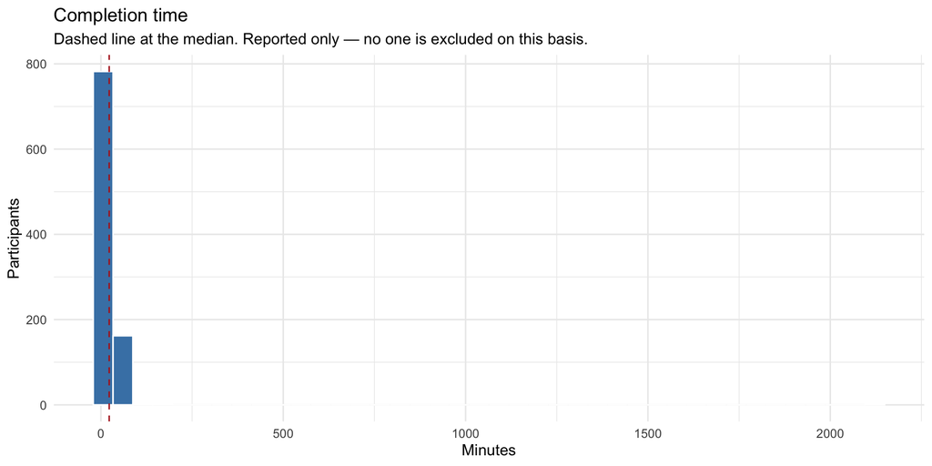

```
## Saved: output/figures/response_quality_duration.png
```

```r
# ===========================================================================
# PHASE 8.2 — COMPLETION-TIME DISTRIBUTION
# ---------------------------------------------------------------------------
# The histogram behind the thresholds in 8.1. Its job is to show whether the
# fast tail is a distinct cluster of speeders or simply the lower end of one
# continuous distribution -- the flags cannot distinguish those two, and the
# subtitle repeats that no one is excluded on this basis.
#
# PRODUCES: output/figures/response_quality_duration.png.
# ===========================================================================
if (sum(!is.na(d$duration_s))) {
  p_dur <- ggplot2::ggplot(d[!is.na(d$duration_s), ],
                           # Plotted in MINUTES for legibility; every threshold
                           # in 8.1 is computed in seconds.
                           ggplot2::aes(x = duration_s / 60)) +
    ggplot2::geom_histogram(bins = 40, fill = "steelblue", colour = "white") +
    # The median line, the anchor all three flags are defined against.
    ggplot2::geom_vline(xintercept = stats::median(d$duration_s, na.rm = TRUE) / 60,
                        linetype = "dashed", colour = "firebrick") +
    ggplot2::labs(title = "Completion time",
                  subtitle = "Dashed line at the median. Reported only — no one is excluded on this basis.",
                  x = "Minutes", y = "Participants") +
    ggplot2::theme_minimal(base_size = 12)
  print(p_dur)
  ggplot2::ggsave(file.path(OUT_FIGURES, "response_quality_duration.png"),
                  p_dur, width = 9, height = 5, dpi = 150)
  cat("Saved: output/figures/response_quality_duration.png\n")
}
```

## 8.2 Long strings of identical answers

```r
# ===========================================================================
# PHASE 8.3 — LONG STRINGS OF IDENTICAL ANSWERS
# ---------------------------------------------------------------------------
# WHAT THIS CHUNK DOES: computes each participant's longest run of identical
# consecutive answers across the attitude battery, and the share of their
# answers at their own modal value.
#
# IMPLEMENTS: the second half of the Section 6.2 diagnostic. Again REPORT ONLY.
#
# WHAT A LONG STRING IS AND IS NOT: it is the classic straight-lining indicator,
# but this battery contains reverse-keyed items scattered throughout, so a
# genuinely consistent respondent should NOT produce a long run -- agreeing with
# both a punitiveness item and its reversed neighbour requires different
# numbers. That is what makes the measure informative here. It is still not
# proof of inattention: a participant who scores 7 on every hostility item in a
# block may simply hold that view strongly.
#
# OBJECTS CREATED: longstring, modal_response, flag_longstring.
# ===========================================================================

# The attitude battery, in questionnaire order, so that a "long string" means a
# run of identical answers as the participant actually saw them. Only the 1-7
# agree/disagree style items are used; sliders and categorical items are not.
# ORDER IS LOAD-BEARING. rle() below finds runs of ADJACENT identical values, so
# this vector must match the presentation order of Sections 5.2 through 5.12; a
# resorted list would report runs the participant never actually produced.
# Excluded by design: the sentence sliders and CRT sliders (a continuous 0-50
# response is not a scale point), the categorical demographics, and both
# attention checks (whose sparse coding would break the run logic and which have
# already done their work in the exclusion funnel).
ls_items <- intersect(c(
  paste0("Retribution_", 1:7), paste0("Deterrence_", 1:3),
  paste0("Incapacitation_", 1:2), paste0("Rehabilitation_", 1:2),
  paste0("Solidarity_", 1:3),
  "punishmore_1", "punishmore_2", "parsimony_1", "parsimony_2",
  "threestrikes_1", "threestrikes_2", "LWOP", "deathpenalty",
  paste0("revenge_", 1:4), "proportionality", "severity_1", "severity_2",
  paste0("exclusion_", 1:3), paste0("essential_", 1:4),
  paste0("Society_", 1:3), paste0("choice_", 1:2),
  paste0("dueprocess_", 1:3), paste0("uncertain_", 1:4),
  paste0("rates_", 1:2), paste0("fear_", 1:3),
  paste0("hate_", 1:3), paste0("anger_", 1:2),
  paste0("degrad_", 1:3), paste0("suffer_", 1:2), paste0("prisonvi_", 1:2),
  paste0("harsh_", 1:3), paste0("rwa_", 1:5), paste0("sdo_", 1:8),
  paste0("vprone_", 1:4), paste0("Raceresent_", 1:4)), names(d))

cat(sprintf("Long-string computed over %d attitude items.\n", length(ls_items)))
```

```
## Long-string computed over 92 attitude items.
```

```r
#' Longest run of identical consecutive values in one participant's row.
#' Arguments: x, one row of the item matrix. Returns: integer run length, or NA.
#' rle() encodes the vector as runs and reports each run's length; the maximum
#' of those lengths is the long-string index. Note that rle() treats each NA as
#' breaking a run, so a skipped item shortens rather than extends the count --
#' the conservative direction for a flag nobody is excluded on.
max_run <- function(x) {
  x <- as.numeric(x)
  if (all(is.na(x))) return(NA_integer_)
  r <- rle(x)
  as.integer(max(r$lengths, na.rm = TRUE))
}
#' Share of a participant's answers sitting at their own most-frequent value.
#' Arguments: x, one row. Returns: proportion in 0-1, or NA for an empty row.
#' This is the POSITION-FREE companion to max_run(): it catches a participant
#' who answered 4 to three quarters of the battery but never in a long
#' consecutive block, which rle() would miss entirely.
modal_share <- function(x) {
  x <- x[!is.na(x)]
  if (!length(x)) return(NA_real_)
  max(table(x)) / length(x)
}

ls_desc <- NULL

# Fewer than 10 items makes a run length uninformative -- with a short battery
# almost any answer pattern produces a "long" relative run.
if (length(ls_items) >= 10) {
  # as.matrix() so apply() walks rows of a uniform numeric matrix. Applying over
  # a data frame would coerce each row through a list and be far slower.
  mat <- as.matrix(d[, ls_items, drop = FALSE])
  d$longstring     <- apply(mat, 1, max_run)
  d$modal_response <- apply(mat, 1, modal_share)

  ls_desc <- data.frame(
    statistic = c("n", "minimum", "median", "mean", "90th percentile",
                  "95th percentile", "maximum"),
    longest_run = c(sum(!is.na(d$longstring)),
                    min(d$longstring, na.rm = TRUE),
                    stats::median(d$longstring, na.rm = TRUE),
                    mean(d$longstring, na.rm = TRUE),
                    stats::quantile(d$longstring, .90, na.rm = TRUE),
                    stats::quantile(d$longstring, .95, na.rm = TRUE),
                    max(d$longstring, na.rm = TRUE)),
    stringsAsFactors = FALSE)

  # 10 consecutive identical answers is the conventional straight-lining
  # threshold, and it is a demanding one in THIS battery: reaching it means
  # giving the same number to ten adjacent items that include reverse-keyed
  # ones. The 15-run count printed below shows how sensitive the tally is to
  # moving the line, which is the honest way to report a threshold that
  # determines nothing.
  d$flag_longstring <- as.integer(d$longstring >= 10)
}

show_table(ls_desc, caption = "Longest run of identical consecutive answers")
```

Longest run of identical consecutive answers

| statistic | longest_run |
| --- | --- |
| n | 948.000 |
| minimum | 2.000 |
| median | 5.000 |
| mean | 5.911 |
| 90th percentile | 11.000 |
| 95th percentile | 13.000 |
| maximum | 60.000 |

```r
if (length(ls_items) >= 10) {
  cat(sprintf("Runs of 10 or more identical answers: %d participants (%s)\n",
              sum(d$flag_longstring, na.rm = TRUE),
              pct(mean(d$flag_longstring, na.rm = TRUE))))
  cat(sprintf("Runs of 15 or more: %d participants (%s)\n",
              sum(d$longstring >= 15, na.rm = TRUE),
              pct(mean(d$longstring >= 15, na.rm = TRUE))))
  cat(sprintf("Median share of responses at the participant's modal value: %s\n",
              pct(stats::median(d$modal_response, na.rm = TRUE))))
  cat("\nDistribution of the longest run:\n")
  print(table(d$longstring, useNA = "ifany"))
} else {
  d$longstring <- NA_integer_
  d$flag_longstring <- NA_integer_
  cat("Too few attitude items present to compute long strings.\n")
}
```

```
## Runs of 10 or more identical answers: 118 participants (12.4%)
## Runs of 15 or more: 38 participants (4.0%)
## Median share of responses at the participant's modal value: 29.3%
##
## Distribution of the longest run:
##
##   2   3   4   5   6   7   8   9  10  11  12  13  14  15  16  17  18  19  21  24
##   8 176 234 178 134  52  36  12  16  10  32  21   1   2   3  26   1   1   1   1
##  32  35  60
##   1   1   1
```

```r
# ===========================================================================
# PHASE 8.4 — RESPONSE-QUALITY FLAG SUMMARY
# ---------------------------------------------------------------------------
# Collects the four flags into one table and builds `flag_any`, the union used
# by the sensitivity comparison in 8.5.
#
# The flags OVERLAP by construction: flag_fast_third is a strict subset of
# flag_fast_half, so the four counts must not be added together. flag_any is
# computed as a union rather than a sum for exactly that reason.
#
# PRODUCES: output/tables/response_quality_flags.csv.
# ===========================================================================
flag_cols <- intersect(c("flag_fast_half", "flag_fast_third", "flag_slow",
                         "flag_longstring"), names(d))
qual <- NULL

if (length(flag_cols)) {
  qual <- data.frame(
    flag = flag_cols,
    n_flagged = sapply(flag_cols, function(f) sum(d[[f]], na.rm = TRUE)),
    # mean() of a 0/1 column is the proportion flagged; na.rm keeps a
    # participant with a missing duration from voiding the whole figure.
    pct_flagged = sapply(flag_cols, function(f) mean(d[[f]], na.rm = TRUE)),
    stringsAsFactors = FALSE)
  # sapply() over a named vector puts the flag names on the rows as well as in
  # the `flag` column; clearing them avoids printing the same labels twice.
  rownames(qual) <- NULL
  # "> 0" makes this a UNION: flagged on at least one indicator. A row sum would
  # double-count the nested speeding flags and produce a meaningless total.
  d$flag_any <- as.integer(rowSums(d[, flag_cols, drop = FALSE], na.rm = TRUE) > 0)
}

show_table(qual, caption = "Response-quality flags (report only)")
```

Response-quality flags (report only)

| flag | n_flagged | pct_flagged |
| --- | --- | --- |
| flag_fast_half | 25 | 0.026 |
| flag_fast_third | 2 | 0.002 |
| flag_slow | 6 | 0.006 |
| flag_longstring | 118 | 0.124 |

```r
if (length(flag_cols)) {
  cat(sprintf("Flagged on at least one indicator: %d of %d (%s)\n",
              sum(d$flag_any, na.rm = TRUE), nrow(d),
              pct(mean(d$flag_any, na.rm = TRUE))))
  cat("These participants REMAIN in every analysis (pre-registration 6.2).\n")
  readr::write_csv(qual, file.path(OUT_TABLES, "response_quality_flags.csv"))
  cat("Wrote output/tables/response_quality_flags.csv\n")
} else {
  cat("No response-quality indicator could be computed from this input.\n")
}
```

```
## Flagged on at least one indicator: 141 of 948 (14.9%)
## These participants REMAIN in every analysis (pre-registration 6.2).
## Wrote output/tables/response_quality_flags.csv
```

```r
# ===========================================================================
# PHASE 8.5 — REPORT-ONLY SENSITIVITY
# ---------------------------------------------------------------------------
# Report-only sensitivity: does E1 look different with flagged participants set
# aside? This is shown to document the flags' consequences, not to justify
# dropping anyone. Section 6.2 is explicit that neither completion time nor a
# long string removes a participant from the analyses, and the reported result
# everywhere else in this document is the full-sample one.
#
# WHAT THIS BUYS: the column that matters is d_change. If setting the flagged
# participants aside barely moves the effect sizes, then the choice not to
# exclude them costs nothing and the preregistered rule is vindicated on the
# data as well as in principle. If it moved them a lot, that would be worth
# saying out loud -- which is why the comparison is printed rather than
# summarized.
#
# E1 under the RANKING definition is used because it is the primary categorical
# grouping; running all four here would multiply the tables without adding to
# the point, which is about the flags rather than about E1.
# ===========================================================================
cmp <- NULL
n_clean <- NA_integer_

if ("flag_any" %in% names(d) && sum(d$flag_any, na.rm = TRUE) > 0) {
  # is.na(flag_any) is KEPT, not dropped: a participant with no duration
  # recorded was never flagged, and excluding them would confound "flagged" with
  # "missing metadata".
  d_clean <- d[is.na(d$flag_any) | d$flag_any == 0, , drop = FALSE]
  n_clean <- nrow(d_clean)

  # Same outcomes, same directions, same helper as Phase 2.1 -- only the sample
  # differs, which is what makes the two columns comparable.
  e1_sens <- run_contrasts(d_clean, e1_vars, "grp_rank", e1_dir,
                           label = "ranking, flagged set aside")
  if (!is.null(e1_sens) && !is.null(e1_rank)) {
    # merge() by outcome name rather than cbind() by position: if a contrast
    # became non-estimable in the smaller sample, its row simply drops out
    # instead of silently pairing the wrong two effect sizes.
    cmp <- merge(
      pick_cols(e1_rank, c("variable", "d", "p_directional")),
      pick_cols(e1_sens, c("variable", "d", "p_directional")),
      by = "variable", suffixes = c("_full", "_sensitivity"))
    # Signed, so the direction of the shift is visible: positive means setting
    # the flagged participants aside made the effect larger.
    cmp$d_change <- cmp$d_sensitivity - cmp$d_full
  }
}

if (!is.na(n_clean))
  cat(sprintf("Sensitivity sample (flagged set aside): N = %d of %d\n",
              n_clean, nrow(d)))
```

```
## Sensitivity sample (flagged set aside): N = 807 of 948
```

```r
show_table(cmp,
           caption = "E1 under the ranking definition: full sample vs. flagged set aside")
```

E1 under the ranking definition: full sample vs. flagged set aside

| variable | d_full | p_directional_full | d_sensitivity | p_directional_sensitivity | d_change |
| --- | --- | --- | --- | --- | --- |
| CRT | 0.025 | 0.645 | 0.016 | 0.586 | -0.009 |
| raceresent | 0.422 | 0.000 | 0.375 | 0.000 | -0.047 |
| rwa | 0.485 | 0.000 | 0.418 | 0.000 | -0.066 |
| sdo | 0.393 | 0.000 | 0.380 | 0.000 | -0.013 |
| vprone | 0.383 | 0.000 | 0.398 | 0.000 | 0.015 |

```r
if (is.na(n_clean))
  cat("No participant was flagged, so no sensitivity comparison is needed.\n")
```

# PHASE 9: SAVE ALL OUTPUT FILES

```r
# ===========================================================================
# PHASE 9.1 — SAVE THE DERIVED VARIABLES
# ---------------------------------------------------------------------------
# WHAT THIS CHUNK DOES: writes the participant-level variables this document
# created, the reliability log, and (if the fallback ran) the exclusion funnel;
# then lists what is on disk.
#
# WRITES: data/cleaned/retribution_supplementary_vars.csv,
#         output/tables/supplementary_reliability.csv,
#         output/tables/exclusion_funnel_supp.csv (fallback path only).
# ===========================================================================

# The supplementary variables derived in this document, keyed by ResponseId so
# they can be merged back without duplicating the scored file that 01 owns.
# ONLY the columns this document adds are exported -- the composites rebuilt in
# Phase 1.2 are deliberately absent, because 01 owns those and writing a second
# copy here would create two files that could drift apart. intersect() means a
# variable that was never computed (the semantic measure, say) is simply omitted
# rather than exported as a column of NA.
keep <- intersect(c("ResponseId", "Vignette", "retributivist", "retribution_rel",
                    "retrib_medsplit", "retrib_tertile", "sentence_ratio",
                    "ratio_medsplit", "semantic_retributivism", "sem_medsplit",
                    "sentence_delta", "sentence2_resid", "sentence2_resid_vig",
                    "libcons", "pros_lean", "duration_s", "longstring",
                    "modal_response", "flag_fast_half", "flag_fast_third",
                    "flag_slow", "flag_longstring", "flag_any"), names(d))

supp <- d[, keep, drop = FALSE]
readr::write_csv(supp, file.path(OUT_DATA, "retribution_supplementary_vars.csv"))
cat(sprintf("Wrote data/cleaned/retribution_supplementary_vars.csv (%d x %d)\n",
            nrow(supp), ncol(supp)))
```

```
## Wrote data/cleaned/retribution_supplementary_vars.csv (948 x 23)
```

```r
# The full reliability log, including the `items` column, so every alpha and
# omega in the appendix can be traced to the exact item list that produced it.
readr::write_csv(alpha_table, file.path(OUT_TABLES, "supplementary_reliability.csv"))
cat("Wrote output/tables/supplementary_reliability.csv\n")
```

```
## Wrote output/tables/supplementary_reliability.csv
```

```r
# Written only when the Phase 1.1 fallback ran, i.e. when this document had to
# apply the exclusions itself. On the normal path 01 owns and reports the funnel
# and there is nothing to duplicate.
if (!is.null(exclusion_funnel)) {
  readr::write_csv(exclusion_funnel, file.path(OUT_TABLES, "exclusion_funnel_supp.csv"))
  cat("Wrote output/tables/exclusion_funnel_supp.csv (funnel reproduced locally)\n")
}

cat("\nFiles in output/tables/:\n")
```

```
##
## Files in output/tables/:
```

```r
print(list.files(OUT_TABLES))
```

```
##  [1] "contrast_measure_agreement.csv"
##  [2] "contrasts_all_measures.csv"
##  [3] "contrasts_continuous_ratio.csv"
##  [4] "contrasts_continuous_sentence_resid.csv"
##  [5] "contrasts_continuous.csv"
##  [6] "contrasts_median_split.csv"
##  [7] "contrasts_ranking.csv"
##  [8] "contrasts_sentencing_ratio.csv"
##  [9] "contrasts_side_by_side.csv"
## [10] "contrasts_tertiles.csv"
## [11] "data_provenance.csv"
## [12] "demographics.csv"
## [13] "descriptives.csv"
## [14] "E1_personality_continuous.csv"
## [15] "E1_personality_contrasts.csv"
```

[output cut: 59 more lines]

```r
cat("\nFiles in output/figures/:\n")
```

```
##
## Files in output/figures/:
```

```r
print(list.files(OUT_FIGURES))
```

```
##  [1] "E1_personality_effects.png"      "e6_backward_minus_forward.png"
##  [3] "EFA_scree_correlates.png"        "H1_correlate_forest.png"
##  [5] "H3_correlate_heatmap.png"        "H3_scree.png"
##  [7] "response_quality_duration.png"   "retributivism_distributions.png"
##  [9] "retributivist_contrasts.png"     "sentence_ratio_by_vignette.png"
## [11] "wordlist_facet_prevalence.png"
```

```r
# ===========================================================================
# PHASE 9.2 — CLOSING SUMMARY
# ---------------------------------------------------------------------------
# A single block a reader can check the knitted document against: which input
# was used, the analysis N, the size of the primary retributivist group, the
# standing of the semantic measure, and the Section 6.6 checklist of everything
# this document was required to deliver.
#
# It closes by restating the multiplicity position, because that is the one
# thing a reader must carry away from every p-value above: no false-discovery
# correction is applied anywhere in this file. Section 6.6 declares two families
# and this document belongs to neither -- the H1 correlation set is corrected in
# 01_main_analysis.Rmd, and E3-E7 are corrected within themselves in
# 02_nlp_integration.Rmd. Everything here is a lead, not a finding.
# ===========================================================================
cat("========================================================================\n")
cat("SUPPLEMENTARY / EXPLORATORY ANALYSES — SUMMARY\n")
```

```
## SUPPLEMENTARY / EXPLORATORY ANALYSES — SUMMARY
```

```r
cat("========================================================================\n\n")
cat(sprintf("Data source : %s\n", DATA_SOURCE))
```

```
## Data source : scored CSV from 01_clean_and_score
```

```r
cat(sprintf("Analysis N  : %d\n", nrow(d)))
```

```
## Analysis N  : 948
```

```r
cat(sprintf("Retributivists (ranking): %d (%s)\n",
            sum(d$retributivist, na.rm = TRUE), pct(mean(d$retributivist, na.rm = TRUE))))
```

```
## Retributivists (ranking): 371 (39.1%)
```

```r
cat(sprintf("Semantic measure: %s\n\n", SEMANTIC_STATUS))
```

```
## Semantic measure: placeholder (no measure available)
```

```r
cat("Delivered in this document (pre-registration 6.6):\n")
```

```
## Delivered in this document (pre-registration 6.6):
```

```r
cat("  E1  personality + CRT between groups, under all four definitions\n")
```

```
##   E1  personality + CRT between groups, under all four definitions
```

```r
cat("  E2  hostile vs Durkheimian solidarity, Steiger's test\n")
```

```
##   E2  hostile vs Durkheimian solidarity, Steiger's test
```

```r
cat("      (Solidarity_1 dropped per 5.3; sensitivity with it included)\n")
```

```
##       (Solidarity_1 dropped per 5.3; sensitivity with it included)
```

```r
cat("  --  factor structure of the correlates (EFA + scree)\n")
```

```
##   --  factor structure of the correlates (EFA + scree)
```

```r
cat("  --  first-to-second sentence change, incl. residualized robustness\n")
```

```
##   --  first-to-second sentence change, incl. residualized robustness
```

```r
cat("  --  political orientation and prosecution-defense leaning as moderators\n")
```

```
##   --  political orientation and prosecution-defense leaning as moderators
```

```r
cat("  --  agreement and overlap among the four retributivist definitions (5.3)\n")
```

```
##   --  agreement and overlap among the four retributivist definitions (5.3)
```

```r
cat("  --  completion time and long strings, report only (6.2)\n\n")
```

```
##   --  completion time and long strings, report only (6.2)
```

```r
cat("Not corrected as a confirmatory family (6.6). No FDR adjustment applied.\n")
```

```
## Not corrected as a confirmatory family (6.6). No FDR adjustment applied.
```

```r
cat("These are exploratory analyses on the full sample; not a confirmatory family.\n")
```

```
## These are exploratory analyses on the full sample; not a confirmatory family.
```